# R Notebook

Installed all Necessary packages for the Project

```r
library(car)
library(pls)
library(caret)
library(randomForest)
library(ggplot2)
library(reshape2)
library(corrplot)
library(ggplot2)
library(ggcorrplot)
library(leaps)
library(glmnet)
library(gbm)
library(keras)
library(tidyverse)
```

# Data Seletion

Read the CSV file and display dimensions of the dataset

```r
data <- read.csv("C:/Users/choun/OneDrive/Desktop/ASL_II/hour.csv")
dim(data)
```

```
[1] 17379    17
```

To display datatype of the each column in the Dataset

```r
str(data)
```

```
'data.frame':   17379 obs. of  17 variables:
 $ instant   : int  1 2 3 4 5 6 7 8 9 10 ...
 $ dteday    : chr  "2011-01-01" "2011-01-01" "2011-01-01" "2011-01-01" ...
 $ season    : int  1 1 1 1 1 1 1 1 1 1 ...
 $ yr        : int  0 0 0 0 0 0 0 0 0 0 ...
 $ mnth      : int  1 1 1 1 1 1 1 1 1 1 ...
 $ hr        : int  0 1 2 3 4 5 6 7 8 9 ...
 $ holiday   : int  0 0 0 0 0 0 0 0 0 0 ...
 $ weekday   : int  6 6 6 6 6 6 6 6 6 6 ...
 $ workingday: int  0 0 0 0 0 0 0 0 0 0 ...
 $ weathersit: int  1 1 1 1 1 2 1 1 1 1 ...
 $ temp      : num  0.24 0.22 0.22 0.24 0.24 0.24 0.22 0.2 0.24 0.32 ...
 $ atemp     : num  0.288 0.273 0.273 0.288 0.288 ...
 $ hum       : num  0.81 0.8 0.8 0.75 0.75 0.75 0.8 0.86 0.75 0.76 ...
 $ windspeed : num  0 0 0 0 0 0.0896 0 0 0 0 ...
 $ casual    : int  3 8 5 3 0 0 2 1 1 8 ...
 $ registered: int  13 32 27 10 1 1 0 2 7 6 ...
 $ cnt       : int  16 40 32 13 1 1 2 3 8 14 ...
```

To display complete summary of the dataset

```r
summary(data)
```

```
    instant         dteday              season            yr              mnth              hr           holiday
 Min.   :    1   Length:17379       Min.   :1.000   Min.   :0.0000   Min.   : 1.000   Min.   : 0.00   Min.   :0.00000
 1st Qu.: 4346   Class :character   1st Qu.:2.000   1st Qu.:0.0000   1st Qu.: 4.000   1st Qu.: 6.00   1st Qu.:0.00000
 Median : 8690   Mode  :character   Median :3.000   Median :1.0000   Median : 7.000   Median :12.00   Median :0.00000
 Mean   : 8690                      Mean   :2.502   Mean   :0.5026   Mean   : 6.538   Mean   :11.55   Mean   :0.02877
 3rd Qu.:13034                      3rd Qu.:3.000   3rd Qu.:1.0000   3rd Qu.:10.000   3rd Qu.:18.00   3rd Qu.:0.00000
 Max.   :17379                      Max.   :4.000   Max.   :1.0000   Max.   :12.000   Max.   :23.00   Max.   :1.00000
    weekday        workingday       weathersit         temp           atemp             hum           windspeed
 Min.   :0.000   Min.   :0.0000   Min.   :1.000   Min.   :0.020   Min.   :0.0000   Min.   :0.0000   Min.   :0.0000
 1st Qu.:1.000   1st Qu.:0.0000   1st Qu.:1.000   1st Qu.:0.340   1st Qu.:0.3333   1st Qu.:0.4800   1st Qu.:0.1045
 Median :3.000   Median :1.0000   Median :1.000   Median :0.500   Median :0.4848   Median :0.6300   Median :0.1940
 Mean   :3.004   Mean   :0.6827   Mean   :1.425   Mean   :0.497   Mean   :0.4758   Mean   :0.6272   Mean   :0.1901
 3rd Qu.:5.000   3rd Qu.:1.0000   3rd Qu.:2.000   3rd Qu.:0.660   3rd Qu.:0.6212   3rd Qu.:0.7800   3rd Qu.:0.2537
 Max.   :6.000   Max.   :1.0000   Max.   :4.000   Max.   :1.000   Max.   :1.0000   Max.   :1.0000   Max.   :0.8507
     casual         registered         cnt
 Min.   :  0.00   Min.   :  0.0   Min.   :  1.0
 1st Qu.:  4.00   1st Qu.: 34.0   1st Qu.: 40.0
 Median : 17.00   Median :115.0   Median :142.0
 Mean   : 35.68   Mean   :153.8   Mean   :189.5
 3rd Qu.: 48.00   3rd Qu.:220.0   3rd Qu.:281.0
 Max.   :367.00   Max.   :886.0   Max.   :977.0
```

# Data PreProcessing

#### Checking relationship between the dteday and yr column

```r
data$Year <- format(as.Date(data$dteday),"%Y")
data$Category <- ifelse(data$Year == "2011", 0, 1)
identical_columns <- identical(data$yr, as.integer(data$Category))
print(identical_columns)
```

```
[1] TRUE
```

#### Checking relationship between the dteday and mnt column

```r
data$month <- format(as.Date(data$dteday),"%m")
identical_columns <- identical(data$mnth, as.integer(data$month))
print(identical_columns)
```

```
[1] TRUE
```

#### Checking relationship between the casual, registered and cnt

```r
data$cnt1 <- data$casual+data$registered
identical_columns <- identical(data$cnt, data$casual+data$registered)
print(identical_columns)
```

```
[1] TRUE
```

#### So we can remove the dteday and other columns we have added for identification

```r
columns_to_remove <- c("dteday", "instant","month","Category","Year","casual","registered","cnt1")
data <- data[, !names(data) %in% columns_to_remove]
```

#### Find and display duplicate rows based on all columns

```r
duplicate_rows <- data[duplicated(data) | duplicated(data, fromLast = TRUE), ]
print("Duplicate Rows in the Dataset:")
```

```
[1] "Duplicate Rows in the Dataset:"
```

```r
print(duplicate_rows)
```

|  | season | yr | mnth | hr | holiday | weekday | workingday | weathersit | temp | atemp | hum | windspeed | cnt |
| --- | --- | --- | --- | --- | --- | --- | --- | --- | --- | --- | --- | --- | --- |
| 7959 | 4 | 0 | 12 | 6 | 0 | 6 | 0 | 1 | 0.24 | 0.2576 | 0.65 | 0.1045 | 11 |
| 8127 | 4 | 0 | 12 | 6 | 0 | 6 | 0 | 1 | 0.24 | 0.2576 | 0.65 | 0.1045 | 11 |
| 13560 | 3 | 1 | 7 | 4 | 0 | 2 | 1 | 1 | 0.66 | 0.6061 | 0.83 | 0.0896 | 6 |
| 13728 | 3 | 1 | 7 | 4 | 0 | 2 | 1 | 1 | 0.66 | 0.6061 | 0.83 | 0.0896 | 6 |

#### Removed the Duplicate Data

```r
data <- unique(data)
```

##Missing or Null Values #### Check for missing values using is.na() function

```r
missing_values <- is.na(data)
```

#### Count missing values in each column

```r
missing_counts <- colSums(missing_values)
```

#### Display the missing values in the dataset

```r
print("Missing Values in the Dataset:")
```

```
[1] "Missing Values in the Dataset:"
```

```r
print(missing_values)
```

[output not shown]

[output cut: 63 more lines]

#### Display the count of missing values in each column

```r
print("Missing Value Counts by Column:")
```

```
[1] "Missing Value Counts by Column:"
```

```r
print(missing_counts)
```

```
    season         yr       mnth         hr    holiday    weekday workingday weathersit       temp      atemp        hum
         0          0          0          0          0          0          0          0          0          0          0
 windspeed        cnt
         0          0
```

Summary of Data

```r
summary(data)
```

```
     season            yr              mnth              hr           holiday           weekday        workingday
 Min.   :1.000   Min.   :0.0000   Min.   : 1.000   Min.   : 0.00   Min.   :0.00000   Min.   :0.000   Min.   :0.0000
 1st Qu.:2.000   1st Qu.:0.0000   1st Qu.: 4.000   1st Qu.: 6.00   1st Qu.:0.00000   1st Qu.:1.000   1st Qu.:0.0000
 Median :3.000   Median :1.0000   Median : 7.000   Median :12.00   Median :0.00000   Median :3.000   Median :1.0000
 Mean   :2.502   Mean   :0.5026   Mean   : 6.537   Mean   :11.55   Mean   :0.02877   Mean   :3.004   Mean   :0.6827
 3rd Qu.:3.000   3rd Qu.:1.0000   3rd Qu.:10.000   3rd Qu.:18.00   3rd Qu.:0.00000   3rd Qu.:5.000   3rd Qu.:1.0000
 Max.   :4.000   Max.   :1.0000   Max.   :12.000   Max.   :23.00   Max.   :1.00000   Max.   :6.000   Max.   :1.0000
   weathersit         temp           atemp             hum           windspeed           cnt
 Min.   :1.000   Min.   :0.020   Min.   :0.0000   Min.   :0.0000   Min.   :0.0000   Min.   :  1.0
 1st Qu.:1.000   1st Qu.:0.340   1st Qu.:0.3333   1st Qu.:0.4800   1st Qu.:0.1045   1st Qu.: 40.0
 Median :1.000   Median :0.500   Median :0.4848   Median :0.6300   Median :0.1940   Median :142.0
 Mean   :1.425   Mean   :0.497   Mean   :0.4758   Mean   :0.6272   Mean   :0.1901   Mean   :189.5
 3rd Qu.:2.000   3rd Qu.:0.660   3rd Qu.:0.6212   3rd Qu.:0.7800   3rd Qu.:0.2537   3rd Qu.:281.0
 Max.   :4.000   Max.   :1.000   Max.   :1.0000   Max.   :1.0000   Max.   :0.8507   Max.   :977.0
```

Separating the numerical and categorical columns

```r
cat_columns <- c("season","yr","mnth","hr","holiday","weekday","workingday","weathersit")
num_columns <- c("temp","atemp","hum","windspeed","cnt")
```

#### Converting the categorical variable into factors

```r
data[cat_columns] <- lapply(data[cat_columns], as.factor)
str(data)
```

```
'data.frame':   17377 obs. of  13 variables:
 $ season    : Factor w/ 4 levels "1","2","3","4": 1 1 1 1 1 1 1 1 1 1 ...
 $ yr        : Factor w/ 2 levels "0","1": 1 1 1 1 1 1 1 1 1 1 ...
 $ mnth      : Factor w/ 12 levels "1","2","3","4",..: 1 1 1 1 1 1 1 1 1 1 ...
 $ hr        : Factor w/ 24 levels "0","1","2","3",..: 1 2 3 4 5 6 7 8 9 10 ...
 $ holiday   : Factor w/ 2 levels "0","1": 1 1 1 1 1 1 1 1 1 1 ...
 $ weekday   : Factor w/ 7 levels "0","1","2","3",..: 7 7 7 7 7 7 7 7 7 7 ...
 $ workingday: Factor w/ 2 levels "0","1": 1 1 1 1 1 1 1 1 1 1 ...
 $ weathersit: Factor w/ 4 levels "1","2","3","4": 1 1 1 1 1 2 1 1 1 1 ...
 $ temp      : num  0.24 0.22 0.22 0.24 0.24 0.24 0.22 0.2 0.24 0.32 ...
 $ atemp     : num  0.288 0.273 0.273 0.288 0.288 ...
 $ hum       : num  0.81 0.8 0.8 0.75 0.75 0.75 0.8 0.86 0.75 0.76 ...
 $ windspeed : num  0 0 0 0 0 0.0896 0 0 0 0 ...
 $ cnt       : int  16 40 32 13 1 1 2 3 8 14 ...
```

#### To display Unique values in each column

```r
for (col_name in names(data)) {
  if (length(unique(data[[col_name]])) < 25) {
    cat(paste("Unique ", col_name,"'s count: ", length(unique(data[[col_name]])), "\n"))
    cat(paste("Unique values: ", paste(unique(data[[col_name]]), collapse = ", "), "\n\n"))
  }
}
```

```
Unique  season 's count:  4
Unique values:  1, 2, 3, 4

Unique  yr 's count:  2
Unique values:  0, 1

Unique  mnth 's count:  12
Unique values:  1, 2, 3, 4, 5, 6, 7, 8, 9, 10, 11, 12

Unique  hr 's count:  24
Unique values:  0, 1, 2, 3, 4, 5, 6, 7, 8, 9, 10, 11, 12, 13, 14, 15, 16, 17, 18, 19, 20, 21, 22, 23

Unique  holiday 's count:  2
Unique values:  0, 1

Unique  weekday 's count:  7
Unique values:  6, 0, 1, 2, 3, 4, 5

Unique  workingday 's count:  2
Unique values:  0, 1

Unique  weathersit 's count:  4
Unique values:  1, 2, 3, 4
```

# Data Visualization or Exploratory Data Analysis

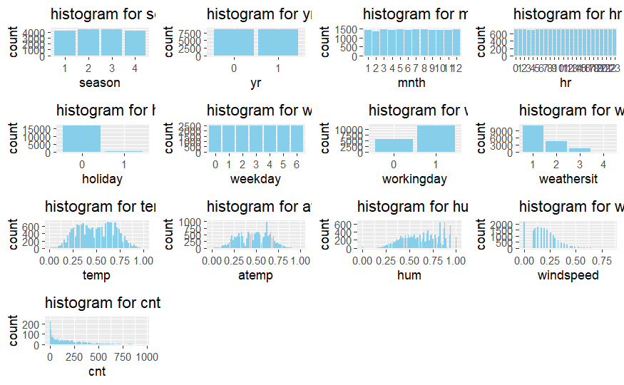

```r
gg_list <- lapply(colnames(data), function(var) {
  ggplot(data, aes(x = data[[var]])) +
    geom_bar(fill = "skyblue") +
    labs(title = paste("histogram for", var),
         x = var)
})

gridExtra::grid.arrange(grobs = gg_list, ncol = 4)
```

# Histogram for Categorocal and Numerical Variables

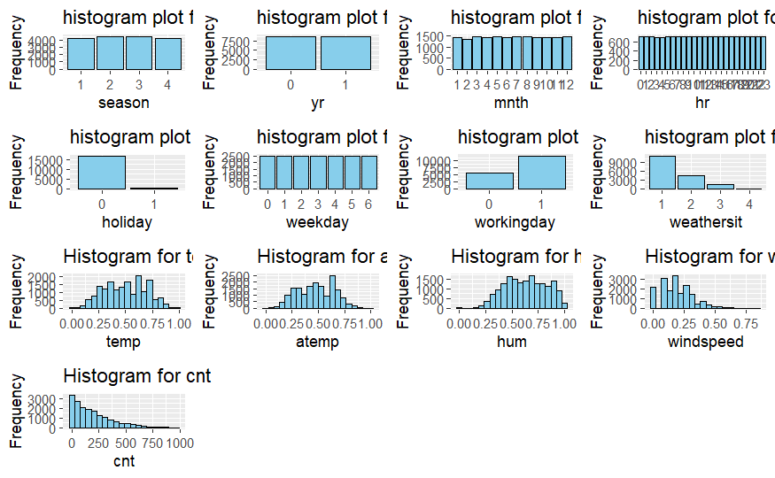

```r
gg_list <- lapply(colnames(data), function(var) {
  if (is.numeric(data[[var]])) {
    ggplot(data, aes(x = data[[var]])) +
      geom_histogram(fill = "skyblue", color = "black", bins = 20) +
      labs(title = paste("Histogram for", var),
           x = var, y = "Frequency")
  } else {
    ggplot(data, aes(x = factor(data[[var]]))) +
      geom_bar(fill = "skyblue", color = "black") +
      labs(title = paste("histogram plot for", var),
           x = var, y = "Frequency")
  }
})

gridExtra::grid.arrange(grobs = gg_list, ncol = 4)
```

# Bar Plot for all categorical Variables against cnt column

```r
# Plot all bar graphs in a 2x4 layout
gg_list <- lapply(cat_columns, function(var) {
  ggplot(data, aes(x = data[[var]], y = cnt)) +
    geom_bar(stat = "identity", position = "dodge", fill = "skyblue") +
    labs(title = paste("Bar Plot for", var),
         x = var, y = "cnt")
})

# Combine the plots into a 2x4 layout
gridExtra::grid.arrange(grobs = gg_list, ncol = 4)
```

[output not shown]

# Box Plot for all categorical Variables against cnt column

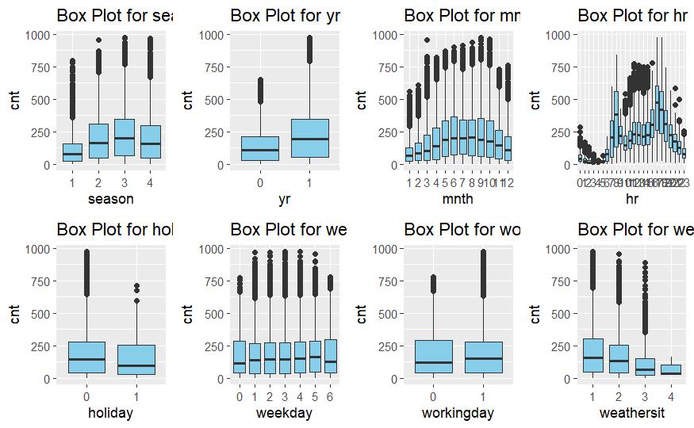

```r
# Plot all box plots in a 2x4 layout
gg_list <- lapply(cat_columns, function(var) {
  ggplot(data, aes(x = data[[var]], y = cnt)) +
    geom_boxplot(fill = "skyblue") +
    labs(title = paste("Box Plot for", var),
         x = var, y = "cnt")
})

# Combine the plots into a 2x4 layout
gridExtra::grid.arrange(grobs = gg_list, ncol = 4)
```

# Scatter plot for all continous variables Against cnt column

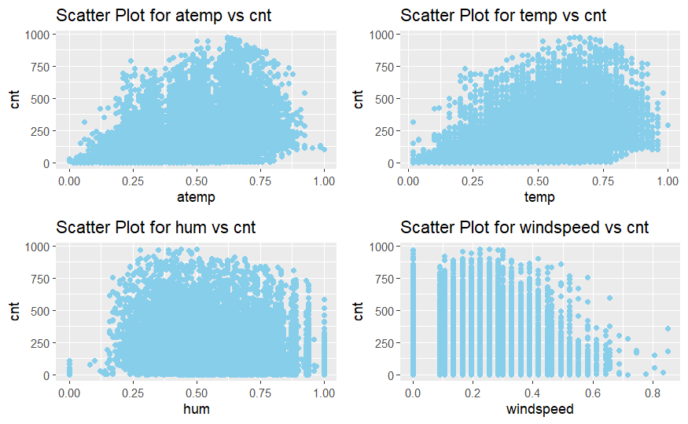

```r
scatter_combinations <- list(c("atemp", "cnt"), c("temp", "cnt"), c("hum", "cnt"), c("windspeed", "cnt"))

# Plot all scatter plots in a 2x2 layout
gg_list <- lapply(scatter_combinations, function(vars) {
  ggplot(data, aes_string(x = vars[1], y = vars[2])) +
    geom_point(color = "skyblue") +
    labs(title = paste("Scatter Plot for", vars[1], "vs", vars[2]),
         x = vars[1], y = vars[2])
})
# Combine the plots into a 2x2 layout
gridExtra::grid.arrange(grobs = gg_list, ncol = 2)
```

```r
cleaned_data <- data
```

# Bar blot of each categorical variable with count

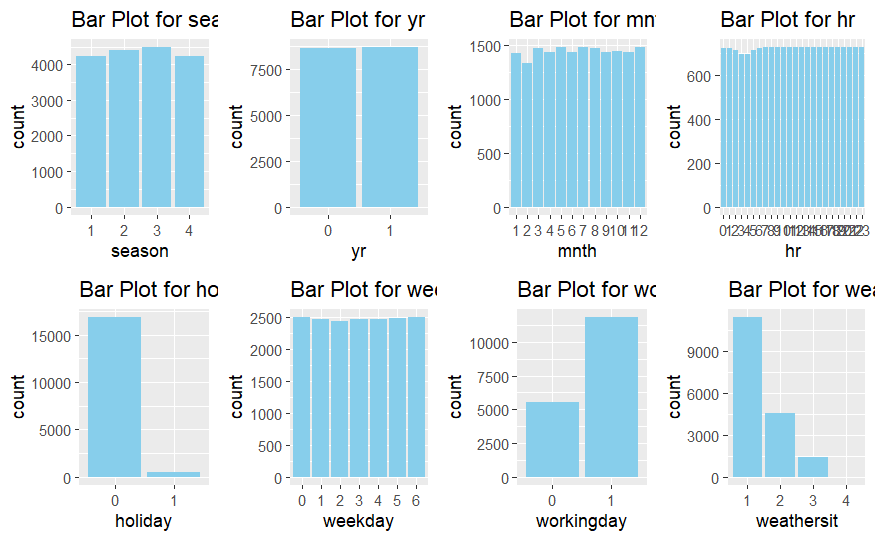

```r
# Plot all bar plots in a 2x4 layout
gg_list <- lapply(cat_columns, function(var) {
  ggplot(data, aes(x = data[[var]])) +
    geom_bar(fill = "skyblue") +
    labs(title = paste("Bar Plot for", var),
         x = var)
})

# Combine the plots into a 2x4 layout
gridExtra::grid.arrange(grobs = gg_list, ncol = 4)
```

# Applying Chi Square test to check association between the two categorical variable

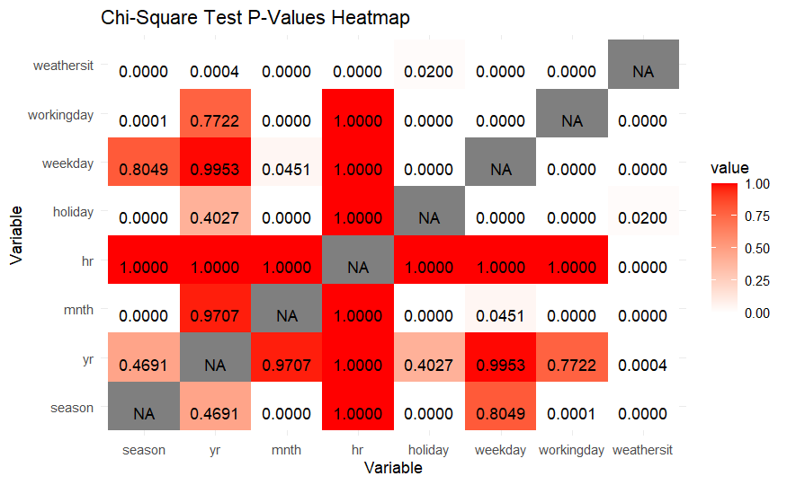

```r
# Create a function to perform chi-square tests and extract p-values
chi_square_test <- function(x, y) {
  contingency_table <- table(data[, x], data[, y])
  chi_square_result <- chisq.test(contingency_table)
  return(chi_square_result$p.value)
}

# Compute p-values for all pairs of categorical variables
variable_names <- cat_columns
p_values <- matrix(NA, nrow = length(variable_names), ncol = length(variable_names))
for (i in 1:length(variable_names)) {
  for (j in 1:length(variable_names)) {
    if (i != j) {
      p_values[i, j] <- chi_square_test(i, j)
    }
  }
}
# Create a heatmap of p-values
colnames(p_values) <- rownames(p_values) <- variable_names
melted_p_values <- melt(p_values)

# Plot heatmap
ggplot(melted_p_values, aes(x = Var1, y = Var2, fill = value)) +
  geom_tile() +
  geom_text(aes(label = sprintf("%.4f", value)), vjust = 1) +
  scale_fill_gradient(low = "white", high = "red") +
  labs(title = "Chi-Square Test P-Values Heatmap", x = "Variable", y = "Variable") +
  theme_minimal()
```

# Correlation between the two continous variable

```r
# Calculate the correlation matrix

#cor_matrix <- cor(data[,c("temp","atemp","hum","windspeed","casual","registered","cnt")])
cor_matrix <- cor(cleaned_data[,c("temp","atemp","hum","windspeed","cnt")])


# Display the correlation matrix
print("Correlation Matrix:")
```

```
[1] "Correlation Matrix:"
```

```r
print(cor_matrix)
```

```
                 temp       atemp         hum   windspeed         cnt
temp       1.00000000  0.98767082 -0.06993080 -0.02314142  0.40479827
atemp      0.98767082  1.00000000 -0.05195988 -0.06235733  0.40094976
hum       -0.06993080 -0.05195988  1.00000000 -0.29006951 -0.32287177
windspeed -0.02314142 -0.06235733 -0.29006951  1.00000000  0.09315481
cnt        0.40479827  0.40094976 -0.32287177  0.09315481  1.00000000
```

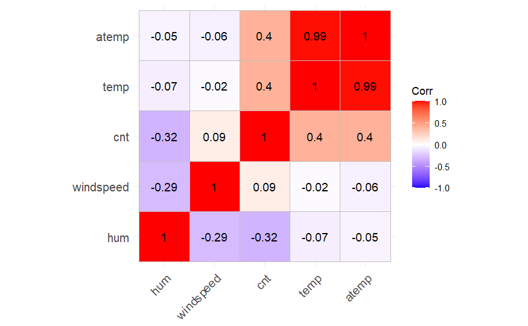

```r
ggcorrplot(cor_matrix, hc.order = TRUE, lab = TRUE)
```

# Feature Selection

### To check the multicollinearity in the data

```r
lm_model <- lm(cnt ~., data = cleaned_data)
aliases <- alias(lm_model)
print(aliases)
```

```
Model :
cnt ~ season + yr + mnth + hr + holiday + weekday + workingday +
    weathersit + temp + atemp + hum + windspeed

Complete :
            (Intercept) season2 season3 season4 yr1 mnth2 mnth3 mnth4 mnth5 mnth6 mnth7 mnth8 mnth9 mnth10 mnth11 mnth12
workingday1  0           0       0       0       0   0     0     0     0     0     0     0     0     0      0      0
            hr1 hr2 hr3 hr4 hr5 hr6 hr7 hr8 hr9 hr10 hr11 hr12 hr13 hr14 hr15 hr16 hr17 hr18 hr19 hr20 hr21 hr22 hr23
workingday1  0   0   0   0   0   0   0   0   0   0    0    0    0    0    0    0    0    0    0    0    0    0    0
            holiday1 weekday1 weekday2 weekday3 weekday4 weekday5 weekday6 weathersit2 weathersit3 weathersit4 temp
workingday1 -1        1        1        1        1        1        0        0           0           0           0
            atemp hum windspeed
workingday1  0     0   0
```

We found workingday is exhibit the multicollinearity with weekday and holiday. So, removed the working day

```r
cleaned_data <- data.frame(cleaned_data[-7])
vif(lm(cnt ~., data = cleaned_data))
```

```
                 GVIF Df GVIF^(1/(2*Df))
season     164.039911  3        2.339690
yr           1.025511  1        1.012675
mnth       320.404735 11        1.299856
hr           1.749201 23        1.012230
holiday      1.117659  1        1.057194
weekday      1.129155  6        1.010174
weathersit   1.394583  3        1.056998
temp        54.217996  1        7.363287
atemp       46.497214  1        6.818887
hum          1.927694  1        1.388414
windspeed    1.249638  1        1.117872
```

```r
df0 <- cleaned_data
df0 <- model.matrix( ~., data = cleaned_data)
df0 <- data.frame(df0[,-1])
lm_model00 <- lm(cnt ~., data = df0)
aliases <- alias(lm_model00)
print(aliases)
```

```
Model :
cnt ~ season2 + season3 + season4 + yr1 + mnth2 + mnth3 + mnth4 +
    mnth5 + mnth6 + mnth7 + mnth8 + mnth9 + mnth10 + mnth11 +
    mnth12 + hr1 + hr2 + hr3 + hr4 + hr5 + hr6 + hr7 + hr8 +
    hr9 + hr10 + hr11 + hr12 + hr13 + hr14 + hr15 + hr16 + hr17 +
    hr18 + hr19 + hr20 + hr21 + hr22 + hr23 + holiday1 + weekday1 +
    weekday2 + weekday3 + weekday4 + weekday5 + weekday6 + weathersit2 +
    weathersit3 + weathersit4 + temp + atemp + hum + windspeed
```

```r
vif(lm(cnt ~., data = df0))
```

```
    season2     season3     season4         yr1       mnth2       mnth3       mnth4       mnth5       mnth6       mnth7
   7.496502   10.642861    7.372719    1.025511    1.837687    2.529913    5.461111    6.453761    6.623530    8.582198
      mnth8       mnth9      mnth10      mnth11      mnth12         hr1         hr2         hr3         hr4         hr5
   8.096229    6.242905    5.401710    4.957063    3.214559    1.915216    1.905712    1.886699    1.889212    1.917311
        hr6         hr7         hr8         hr9        hr10        hr11        hr12        hr13        hr14        hr15
   1.926404    1.925050    1.920441    1.924446    1.940440    1.969384    2.005904    2.036470    2.059537    2.067578
       hr16        hr17        hr18        hr19        hr20        hr21        hr22        hr23    holiday1    weekday1
   2.061599    2.037514    2.005464    1.968043    1.946636    1.930819    1.923576    1.920427    1.117659    1.814707
   weekday2    weekday3    weekday4    weekday5    weekday6 weathersit2 weathersit3 weathersit4        temp       atemp
   1.715821    1.724619    1.723533    1.722039    1.719154    1.195371    1.318475    1.005119   54.217996   46.497214
        hum   windspeed
   1.927694    1.249638
```

# Transformation

Scaled the Data using the Z Normalization

```r
df000 <- df0[,-ncol(df0)]
scale_data <- scale(df000, center = apply(df000, 2, mean), scale = apply(df000, 2, sd))
cnt <- cleaned_data$cnt
scale_data <- data.frame(scale_data,cnt)
dff <- scale_data
```

# Model Selection and Model Training

## Linear Regression

Performed the Linear Regression with 5 fold validation

```r
set.seed(123)
trainIndex <- createDataPartition(dff$cnt, p = 0.8, list = FALSE)
ctrl <- trainControl(method = "cv", number = 5)
lm.fit <- train(cnt ~., data = dff[trainIndex, ], method = "lm",  trControl = ctrl)

lm.summary <- summary(lm.fit)
lm.summary
```

```
Call:
lm(formula = .outcome ~ ., data = dat)

Residuals:
    Min      1Q  Median      3Q     Max
-398.75  -60.55   -7.77   51.05  434.65

Coefficients:
            Estimate Std. Error t value Pr(>|t|)
(Intercept) 189.3061     0.8689 217.856  < 2e-16 ***
season2      16.4860     2.3838   6.916 4.86e-12 ***
season3      13.5262     2.8407   4.762 1.94e-06 ***
season4      29.8907     2.3664  12.632  < 2e-16 ***
yr1          42.2000     0.8798  47.967  < 2e-16 ***
mnth2         1.3089     1.1856   1.104 0.269622
mnth3         4.5463     1.3910   3.268 0.001084 **
mnth4         2.3462     2.0319   1.155 0.248238
mnth5         5.9408     2.2091   2.689 0.007169 **
mnth6         2.0166     2.2367   0.902 0.367290
mnth7        -2.5806     2.5506  -1.012 0.311672
mnth8         3.0686     2.4793   1.238 0.215848
mnth9         9.5621     2.1750   4.396 1.11e-05 ***
mnth10        3.3400     2.0172   1.656 0.097786 .
mnth11       -2.5354     1.9353  -1.310 0.190189
mnth12       -2.3262     1.5633  -1.488 0.136775
hr1          -3.2326     1.1936  -2.708 0.006769 **
hr2          -5.3062     1.2112  -4.381 1.19e-05 ***
hr3          -6.9872     1.1865  -5.889 3.98e-09 ***
hr4          -8.2105     1.1986  -6.850 7.71e-12 ***
hr5          -4.3293     1.2082  -3.583 0.000340 ***
hr6           7.1923     1.2100   5.944 2.84e-09 ***
hr7          34.0568     1.2160  28.008  < 2e-16 ***
hr8          62.3025     1.1982  51.996  < 2e-16 ***
hr9          32.5377     1.2050  27.002  < 2e-16 ***
hr10         21.4447     1.2098  17.726  < 2e-16 ***
hr11         27.1318     1.2265  22.122  < 2e-16 ***
hr12         34.9093     1.2336  28.298  < 2e-16 ***
hr13         33.7768     1.2392  27.257  < 2e-16 ***
hr14         30.6301     1.2548  24.410  < 2e-16 ***
hr15         32.9846     1.2408  26.584  < 2e-16 ***
```

[output cut: 13 more lines]

```
weekday5      6.3017     1.1467   5.496 3.96e-08 ***
weekday6      5.3481     1.1412   4.686 2.81e-06 ***
weathersit2  -4.7862     0.9498  -5.039 4.73e-07 ***
weathersit3 -18.6500     1.0008 -18.635  < 2e-16 ***
weathersit4  -0.8511     0.7794  -1.092 0.274861
temp         25.5675     6.1963   4.126 3.71e-05 ***
atemp        18.0229     5.7242   3.149 0.001644 **
hum         -15.2839     1.2053 -12.681  < 2e-16 ***
windspeed    -2.6369     0.9762  -2.701 0.006918 **
---
Signif. codes:  0 ‘***’ 0.001 ‘**’ 0.01 ‘*’ 0.05 ‘.’ 0.1 ‘ ’ 1

Residual standard error: 102.4 on 13849 degrees of freedom
Multiple R-squared:  0.6844,    Adjusted R-squared:  0.6833
F-statistic: 577.6 on 52 and 13849 DF,  p-value: < 2.2e-16
```

####Plotted the Actual Values Vs Predicted Values

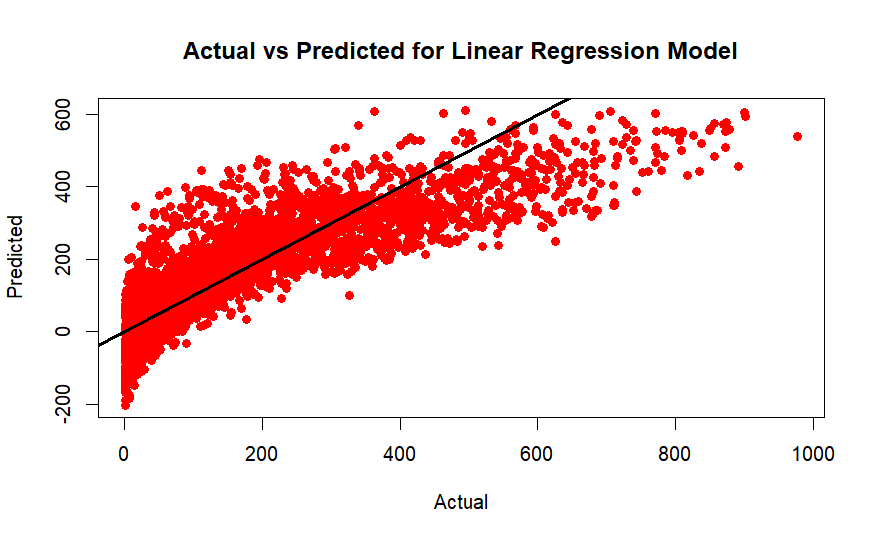

```r
predictions = predict(lm.fit,dff[-trainIndex, ])
plot(dff[-trainIndex, ]$cnt, predictions, pch = 16, col = "red", main = "Actual vs Predicted for Linear Regression Model", xlab = "Actual", ylab = "Predicted")

abline(a = 0, b = 1, col = "black",lty=1,lwd=3)
```

#### Evaluation Metrics for Linear Regression Model

```r
actual_values <- dff[-trainIndex, ]$cnt
r_squared_lm <- 1 - sum((actual_values - predictions)^2) / sum((actual_values - mean(actual_values))^2)
mse_lm <- mean((actual_values - predictions)^2)
rmse_lm <- sqrt(mean((actual_values - predictions)^2))
mae_lm <- mean(abs(actual_values-predictions))


# Display the results
cat("R-squared: ", r_squared_lm, "\n")
```

```
R-squared:  0.6929337
```

```r
cat("Mean Square Error (MSE): ", mse_lm, "\n")
```

```
Mean Square Error (MSE):  9841.131
```

```r
cat("Root Mean Square Error (RMSE): ", rmse_lm, "\n")
```

```
Root Mean Square Error (RMSE):  99.20247
```

```r
cat("Mean Average Error (MAE): ", mae_lm, "\n")
```

```
Mean Average Error (MAE):  74.1543
```

## Linear Regression with Interaction Terms

####Checking the interaction terms randomly for few variables ##### Interaction Terms

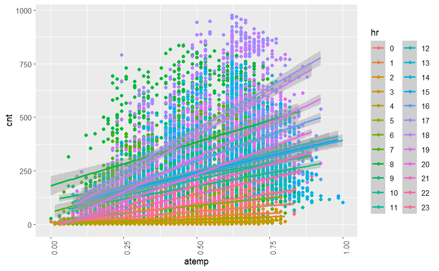

```r
qplot(atemp, cnt, data = cleaned_data, colour = hr) +
  theme(axis.text.x = element_text(angle = 90, hjust = 1)) +
  stat_smooth(method = "lm")
```

##### Interaction Terms

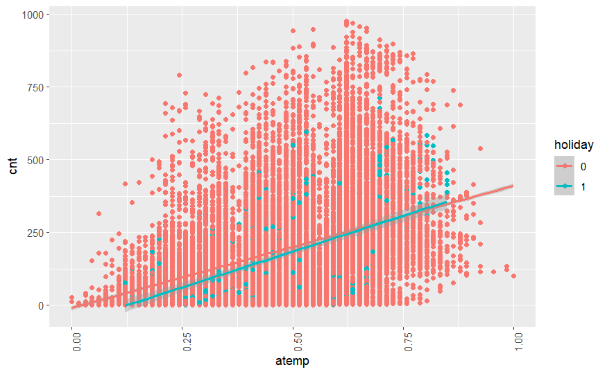

```r
qplot(atemp, cnt, data = cleaned_data, colour = holiday) +
  theme(axis.text.x = element_text(angle = 90, hjust = 1)) +
  stat_smooth(method = "lm")
```

##### Non Interaction Terms

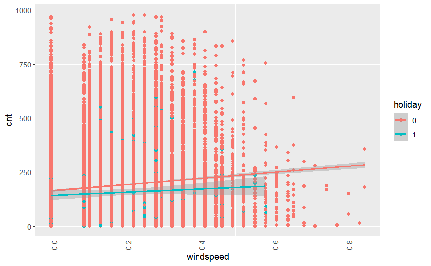

```r
qplot(windspeed, cnt, data = cleaned_data, colour = holiday) +
  theme(axis.text.x = element_text(angle = 90, hjust = 1)) +
  stat_smooth(method = "lm")
```

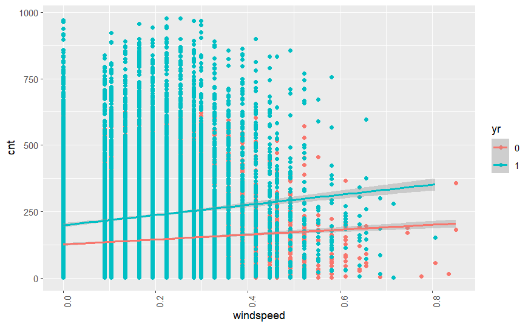

```r
qplot(windspeed, cnt, data = cleaned_data, colour =yr ) +
  theme(axis.text.x = element_text(angle = 90, hjust = 1)) +
  stat_smooth(method = "lm")
```

It is difficult to find the interaction terms. So, build a linear regression model with all possible interaction terms and find the muliticollinearity

```r
library(gridExtra)
#grid.arrange(p2)
interaction_terms <- model.matrix(~.^2, data = cleaned_data[,-12])

# Fit a linear regression model with interaction terms
model <- lm(cnt ~ . -1, data = data.frame(interaction_terms))
alias_terms <- alias(model)$Complete
alias_vars <- rownames(alias_terms)
nnn <- names(data.frame(interaction_terms))
result_col <- setdiff(nnn, alias_vars)
result_col
```

```
  [1] "X.Intercept."          "season2"               "season3"               "season4"
  [5] "yr1"                   "mnth2"                 "mnth3"                 "mnth4"
  [9] "mnth5"                 "mnth6"                 "mnth7"                 "mnth8"
 [13] "mnth9"                 "mnth10"                "mnth11"                "mnth12"
 [17] "hr1"                   "hr2"                   "hr3"                   "hr4"
 [21] "hr5"                   "hr6"                   "hr7"                   "hr8"
 [25] "hr9"                   "hr10"                  "hr11"                  "hr12"
 [29] "hr13"                  "hr14"                  "hr15"                  "hr16"
 [33] "hr17"                  "hr18"                  "hr19"                  "hr20"
 [37] "hr21"                  "hr22"                  "hr23"                  "holiday1"
 [41] "weekday1"              "weekday2"              "weekday3"              "weekday4"
 [45] "weekday5"              "weekday6"              "weathersit2"           "weathersit3"
 [49] "weathersit4"           "temp"                  "atemp"                 "hum"
 [53] "windspeed"             "season2.yr1"           "season3.yr1"           "season4.yr1"
 [57] "season2.mnth3"         "season2.hr1"           "season3.hr1"           "season4.hr1"
```

[output cut: 226 more lines]

Most significant interaction terms

```r
summary_table <- summary(model)
#significant_terms <- summary_table$coefficients
significant_terms <- summary_table$coefficients[summary_table$coefficients[, "Pr(>|t|)"] < 0.05, ]
# Print significant terms
print(significant_terms)
```

```
                        Estimate Std. Error    t value      Pr(>|t|)
X.Intercept.           70.757479  19.336317   3.659305  2.536926e-04
season3               216.604553  36.454050   5.941852  2.875193e-09
yr1                   -30.053509   7.312774  -4.109728  3.980501e-05
mnth3                 -71.137906  17.833289  -3.989051  6.662581e-05
mnth4                 -77.048085  35.083232  -2.196151  2.809505e-02
mnth6                 123.472801  43.054856   2.867802  4.138607e-03
mnth7                 193.806324  56.020827   3.459541  5.424719e-04
mnth8                -138.517079  52.113799  -2.657973  7.868833e-03
mnth11                -67.729305  30.865756  -2.194319  2.822647e-02
hr4                   -44.159367  20.574697  -2.146295  3.186407e-02
hr5                   -53.381159  20.516705  -2.601839  9.280869e-03
hr6                   -83.133108  20.393383  -4.076475  4.593902e-05
hr7                  -175.311131  20.288575  -8.640879  6.084685e-18
hr8                  -186.424599  20.029524  -9.307490  1.470640e-20
hr9                   -44.621237  19.569871  -2.280099  2.261461e-02
hr10                   70.012270  19.278582   3.631609  2.825173e-04
hr11                   87.472942  19.334404   4.524212  6.104609e-06
hr12                  131.249028  19.308334   6.797532  1.100904e-11
hr13                  125.935385  19.413144   6.487120  8.999488e-11
hr14                  122.959031  19.480804   6.311805  2.828767e-10
hr15                  105.341919  19.486005   5.406030  6.533716e-08
hr17                 -113.246302  19.381776  -5.842927  5.226254e-09
hr18                 -130.860319  19.311693  -6.776222  1.275534e-11
hr19                  -68.989748  19.317218  -3.571412  3.560770e-04
hr20                  -76.815383  19.196823  -4.001463  6.322824e-05
hr21                  -78.581346  19.461821  -4.037718  5.421881e-05
hr22                  -68.058618  19.471140  -3.495359  4.746745e-04
hr23                  -62.351562  19.784085  -3.151602  1.626693e-03
weekday1              -60.365194  12.558868  -4.806579  1.548940e-06
weekday2              -55.863438  12.824462  -4.356006  1.332603e-05
weekday3              -65.836724  12.709067  -5.180295  2.241557e-07
weekday4              -66.557054  12.490993  -5.328404  1.003877e-07
weekday5              -47.614644  12.487571  -3.812963  1.378129e-04
weathersit2            37.430006   8.487324   4.410107  1.039766e-05
weathersit3           194.102517  16.999372  11.418217  4.404611e-30
temp                  413.961152 171.583120   2.412598  1.585016e-02
atemp                -407.026779 179.136073  -2.272165  2.308940e-02
season2.yr1            28.928492   6.610599   4.376077  1.215803e-05
season4.yr1            25.049920   6.612701   3.788152  1.523134e-04
```

[output cut: 197 more lines]

```
hr20.weekday2         158.077554  10.097549  15.655042  7.649312e-55
hr21.weekday2         128.722834  10.059173  12.796562  2.583979e-37
hr22.weekday2         104.186967  10.043809  10.373252  3.924253e-25
hr23.weekday2          81.536924  10.036111   8.124354  4.814792e-16
hr3.weekday3           33.861877  10.095310   3.354219  7.976955e-04
hr4.weekday3           54.057136  10.173203   5.313679  1.088369e-07
hr5.weekday3           76.829350  10.107253   7.601408  3.087083e-14
hr6.weekday3          151.020381  10.043966  15.035931  9.298451e-51
hr7.weekday3          334.102631  10.002568  33.401687 1.012141e-236
hr8.weekday3          476.333312  10.006445  47.602652  0.000000e+00
hr9.weekday3          148.282057  10.031355  14.781857  3.969704e-49
hr10.weekday3         -61.907147  10.079692  -6.141770  8.348698e-10
hr11.weekday3         -94.122784  10.160022  -9.264033  2.207080e-20
hr12.weekday3        -106.347694  10.261640 -10.363616  4.337711e-25
 [ reached getOption("max.print") -- omitted 129 rows ]
```

#### Performing the Linear Regression with most significant interaction terms

```r
ctrl <- trainControl(method = "cv", number = 5)
lm.fit_it <- train(cnt ~.+(holiday*atemp)+(temp*atemp)+(season*yr)+(yr*atemp)+(hr*holiday)+(season*hr)+
                     (yr*hr)+(mnth*hr)+(yr*hr)+(mnth*hr)+(yr*hr)+(mnth*hum)+(yr*mnth)+(hr*weekday),
                   data = cleaned_data[trainIndex, ],method="lm",trControl = ctrl)

lm.summary_it <- summary(lm.fit_it)
lm.summary_it
```

```
Call:
lm(formula = .outcome ~ ., data = dat)

Residuals:
    Min      1Q  Median      3Q     Max
-471.46  -24.72   -0.66   27.37  458.02

Coefficients:
                  Estimate Std. Error t value Pr(>|t|)
(Intercept)        25.4113    12.4849   2.035 0.041835 *
season2            -6.8703    14.7611  -0.465 0.641627
season3            -5.4973    18.4210  -0.298 0.765385
season4            -1.6012    16.1243  -0.099 0.920897
yr1               -47.1773     6.6346  -7.111 1.21e-12 ***
mnth2             -25.7637    14.8869  -1.731 0.083542 .
mnth3             -43.4961    15.4770  -2.810 0.004956 **
mnth4              12.1285    21.4464   0.566 0.571724
mnth5              66.0083    22.5466   2.928 0.003421 **
mnth6              21.5619    21.8351   0.987 0.323421
mnth7             -28.5266    25.2783  -1.129 0.259129
mnth8              47.7246    25.3290   1.884 0.059562 .
mnth9             141.9655    24.9531   5.689 1.30e-08 ***
mnth10             96.3250    23.4073   4.115 3.89e-05 ***
mnth11             -1.9748    22.9411  -0.086 0.931403
mnth12             24.4982    19.0431   1.286 0.198305
hr1                 8.5007    14.7250   0.577 0.563751
hr2                 3.5762    14.8883   0.240 0.810177
hr3               -19.6852    14.9791  -1.314 0.188807
hr4               -34.9432    15.6153  -2.238 0.025254 *
hr5               -42.4585    14.9577  -2.839 0.004538 **
hr6               -81.8669    14.9351  -5.482 4.29e-08 ***
hr7              -177.4727    15.1346 -11.726  < 2e-16 ***
hr8              -197.5470    14.6310 -13.502  < 2e-16 ***
hr9               -33.8585    14.8944  -2.273 0.023028 *
hr10               72.6361    14.8621   4.887 1.03e-06 ***
hr11              105.9849    14.9000   7.113 1.19e-12 ***
hr12              121.5649    14.6623   8.291  < 2e-16 ***
hr13              111.1856    14.5734   7.629 2.52e-14 ***
hr14              125.1786    15.0218   8.333  < 2e-16 ***
hr15              100.3094    14.6421   6.851 7.67e-12 ***
```

[output cut: 161 more lines]

```
`mnth9:hr2`       -30.6523    28.0249  -1.094 0.274084
`mnth10:hr2`      -29.6378    27.7434  -1.068 0.285412
`mnth11:hr2`      -11.5817    27.6573  -0.419 0.675400
`mnth12:hr2`      -13.1250    22.3477  -0.587 0.557004
`mnth2:hr3`        -4.2622    17.7005  -0.241 0.809718
`mnth3:hr3`        -7.6630    18.4342  -0.416 0.677642
`mnth4:hr3`        -0.5897    26.7212  -0.022 0.982392
`mnth5:hr3`       -25.5080    26.5778  -0.960 0.337200
 [ reached getOption("max.print") -- omitted 387 rows ]
---
Signif. codes:  0 ‘***’ 0.001 ‘**’ 0.01 ‘*’ 0.05 ‘.’ 0.1 ‘ ’ 1

Residual standard error: 57.79 on 13315 degrees of freedom
Multiple R-squared:  0.9034,    Adjusted R-squared:  0.8991
F-statistic: 212.5 on 586 and 13315 DF,  p-value: < 2.2e-16
```

####Plotted the Actual Values Vs Predicted Values

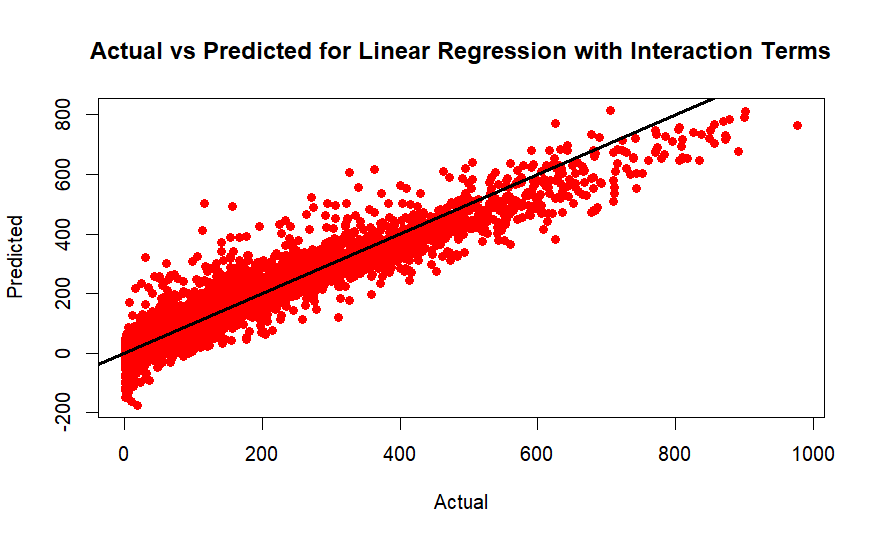

```r
predictions = predict(lm.fit_it,cleaned_data[-trainIndex, ])
plot(cleaned_data[-trainIndex, ]$cnt, predictions, pch = 16, col = "red", main = "Actual vs Predicted for Linear Regression with Interaction Terms", xlab = "Actual", ylab = "Predicted")

abline(a = 0, b = 1, col = "black",lty=1,lwd=3)
```

#### Evaluation Metrics for Linear Regression Model with Interaction Terms

```r
actual_values <- cleaned_data[-trainIndex, ]$cnt
r_squared_it <- 1 - sum((actual_values - predictions)^2) / sum((actual_values - mean(actual_values))^2)
mse_it <- mean((actual_values - predictions)^2)
rmse_it <- sqrt(mean((actual_values - predictions)^2))
mae_it <- mean(abs(actual_values-predictions))
cat("Mean Average Error (MAE): ", mae_it, "\n")
```

```
Mean Average Error (MAE):  39.59739
```

```r
# Display the results
cat("R-squared: ", r_squared_it, "\n")
```

```
R-squared:  0.8994243
```

```r
cat("Mean Square Error (MsE): ", mse_it, "\n")
```

```
Mean Square Error (MsE):  3223.339
```

```r
cat("Root Mean Square Error (RMSE): ", rmse_it, "\n")
```

```
Root Mean Square Error (RMSE):  56.77445
```

## Linear Regression with Polynomial of Degree 2

Performed all numerical column with degree 2 and found whether exhibit multicolinearity or not

```r
### Polynomial degree 2
predictors <- num_columns[-c(5)]
poly_de2 <- data.frame(cleaned_data)
for(predictor in predictors) {
  poly_de2[paste(predictor, "de-2", sep = "-")] <- cleaned_data[predictor]^2
}
poly_de2 <- data.frame(poly_de2)
df02 <- model.matrix( ~., data = poly_de2)
df02 <- data.frame(df02[,-1])
lm_model00 <- lm(cnt ~., data = data.frame(df02))
aliases <- alias(lm_model00)
print(aliases)
```

```
Model :
cnt ~ season2 + season3 + season4 + yr1 + mnth2 + mnth3 + mnth4 +
    mnth5 + mnth6 + mnth7 + mnth8 + mnth9 + mnth10 + mnth11 +
    mnth12 + hr1 + hr2 + hr3 + hr4 + hr5 + hr6 + hr7 + hr8 +
    hr9 + hr10 + hr11 + hr12 + hr13 + hr14 + hr15 + hr16 + hr17 +
    hr18 + hr19 + hr20 + hr21 + hr22 + hr23 + holiday1 + weekday1 +
    weekday2 + weekday3 + weekday4 + weekday5 + weekday6 + weathersit2 +
    weathersit3 + weathersit4 + temp + atemp + hum + windspeed +
    temp.de.2 + atemp.de.2 + hum.de.2 + windspeed.de.2
```

```r
vif(lm(cnt ~., data = data.frame(df02)))
```

```
       season2        season3        season4            yr1          mnth2          mnth3          mnth4          mnth5
      7.508072      10.701760       7.407616       1.037938       1.891983       2.681637       5.659428       6.582641
         mnth6          mnth7          mnth8          mnth9         mnth10         mnth11         mnth12            hr1
      6.685988       8.675557       8.223478       6.473817       5.657138       5.140871       3.316742       1.915366
           hr2            hr3            hr4            hr5            hr6            hr7            hr8            hr9
      1.906364       1.887639       1.891060       1.919792       1.930073       1.927912       1.922532       1.926887
          hr10           hr11           hr12           hr13           hr14           hr15           hr16           hr17
      1.943362       1.971455       2.008692       2.040065       2.065843       2.075626       2.069396       2.043150
          hr18           hr19           hr20           hr21           hr22           hr23       holiday1       weekday1
      2.007829       1.968867       1.947363       1.931345       1.923854       1.920727       1.119953       1.816185
      weekday2       weekday3       weekday4       weekday5       weekday6    weathersit2    weathersit3    weathersit4
      1.716787       1.724925       1.723770       1.722754       1.721515       1.198948       1.390975       1.005553
          temp          atemp            hum      windspeed      temp.de.2     atemp.de.2       hum.de.2 windspeed.de.2
    473.866148     460.646442      44.715416       7.672180     393.093203     396.358774      44.462290       7.204376
```

Scaled down the variables using Z Normalization

```r
df000 <- df02[,-53]
scale_data <- scale(df000, center = apply(df000, 2, mean), scale = apply(df000, 2, sd))
cnt <- cleaned_data$cnt
scale_data <- data.frame(scale_data,cnt)
poly_de2 <- scale_data
```

#### Performed the Linear Regression with polynomial of Degree 2 with 5 fold validation

```r
lm.fit_2 <- train(cnt ~ ., data = poly_de2[trainIndex, ], method = "lm",  trControl = ctrl)
lm.summary_2 <- summary(lm.fit_2)
lm.summary_2
```

```
Call:
lm(formula = .outcome ~ ., data = dat)

Residuals:
    Min      1Q  Median      3Q     Max
-380.97  -60.71   -7.34   51.04  443.42

Coefficients:
                Estimate Std. Error t value Pr(>|t|)
(Intercept)     189.2499     0.8662 218.479  < 2e-16 ***
season2          16.4024     2.3783   6.897 5.55e-12 ***
season3          12.3547     2.8400   4.350 1.37e-05 ***
season4          29.4616     2.3645  12.460  < 2e-16 ***
yr1              42.1460     0.8824  47.762  < 2e-16 ***
mnth2             2.1204     1.1980   1.770 0.076748 .
mnth3             5.7804     1.4269   4.051 5.13e-05 ***
mnth4             3.3612     2.0614   1.631 0.103010
mnth5             6.3560     2.2239   2.858 0.004269 **
mnth6             1.9155     2.2405   0.855 0.392591
mnth7            -2.4361     2.5574  -0.953 0.340827
mnth8             3.2589     2.4908   1.308 0.190773
mnth9            10.6735     2.2081   4.834 1.35e-06 ***
mnth10            4.3673     2.0593   2.121 0.033958 *
mnth11           -1.9430     1.9645  -0.989 0.322651
mnth12           -1.8649     1.5830  -1.178 0.238776
hr1              -3.2198     1.1898  -2.706 0.006813 **
hr2              -5.2661     1.2075  -4.361 1.30e-05 ***
hr3              -6.8528     1.1831  -5.792 7.09e-09 ***
hr4              -8.1091     1.1953  -6.784 1.21e-11 ***
hr5              -4.3268     1.2050  -3.591 0.000331 ***
hr6               7.2380     1.2074   5.995 2.09e-09 ***
hr7              33.9192     1.2129  27.965  < 2e-16 ***
hr8              62.1164     1.1950  51.978  < 2e-16 ***
hr9              32.4102     1.2019  26.966  < 2e-16 ***
hr10             21.2030     1.2068  17.570  < 2e-16 ***
hr11             26.9091     1.2232  21.999  < 2e-16 ***
hr12             34.8329     1.2307  28.304  < 2e-16 ***
hr13             33.7457     1.2364  27.295  < 2e-16 ***
hr14             30.5453     1.2529  24.379  < 2e-16 ***
hr15             32.9666     1.2387  26.613  < 2e-16 ***
```

[output cut: 17 more lines]

```
weathersit4      -0.7887     0.7772  -1.015 0.310216
temp            -83.2052    18.9186  -4.398 1.10e-05 ***
atemp           121.4054    18.6470   6.511 7.74e-11 ***
hum              16.0025     5.7774   2.770 0.005615 **
windspeed        11.2596     2.4375   4.619 3.89e-06 ***
temp.de.2       109.7080    17.3587   6.320 2.69e-10 ***
atemp.de.2     -102.5755    17.3845  -5.900 3.71e-09 ***
hum.de.2        -31.1910     5.7581  -5.417 6.16e-08 ***
windspeed.de.2  -12.8389     2.3889  -5.374 7.81e-08 ***
---
Signif. codes:  0 ‘***’ 0.001 ‘**’ 0.01 ‘*’ 0.05 ‘.’ 0.1 ‘ ’ 1

Residual standard error: 102.1 on 13845 degrees of freedom
Multiple R-squared:  0.6866,    Adjusted R-squared:  0.6853
F-statistic: 541.5 on 56 and 13845 DF,  p-value: < 2.2e-16
```

####Plotted the Actual Values Vs Predicted Values

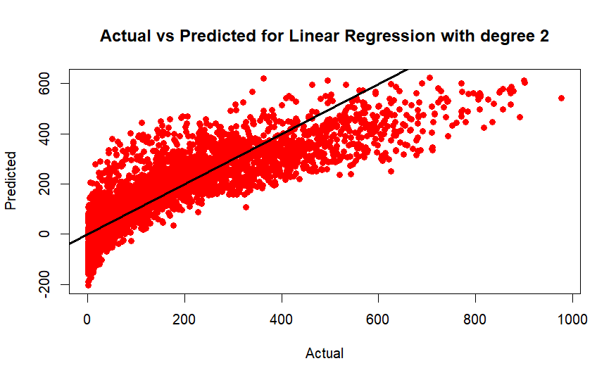

```r
predictions = predict(lm.fit_2,poly_de2[-trainIndex,])
plot(poly_de2[-trainIndex,]$cnt, predictions, pch = 16, col = "red", main = "Actual vs Predicted for Linear Regression with degree 2", xlab = "Actual", ylab = "Predicted")

abline(a = 0, b = 1, col = "black",lty=1,lwd=3)
```

####Evaluation Metrics for Linear Regression Model of Polynomial of Degree 2

```r
actual_values <- poly_de2[-trainIndex,]$cnt
r_squared_lm2 <- 1 - sum((actual_values - predictions)^2) / sum((actual_values - mean(actual_values))^2)
mse_lm2 <- mean((actual_values - predictions)^2)
rmse_lm2 <- sqrt(mean((actual_values - predictions)^2))
mae_lm2 <- mean(abs(actual_values-predictions))

# Display the results
cat("R-squared: ", r_squared_lm2, "\n")
```

```
R-squared:  0.6954175
```

```r
cat("Mean Square Error (MSE): ", mse_lm2, "\n")
```

```
Mean Square Error (MSE):  9761.529
```

```r
cat("Root Mean Square Error (RMSE): ", rmse_lm2, "\n")
```

```
Root Mean Square Error (RMSE):  98.80045
```

```r
cat("Mean Average Error (MAE): ", mae_lm2, "\n")
```

```
Mean Average Error (MAE):  73.66787
```

## Linear Regression with Polynomial of Degree 3

Performed all numerical column with degree 3 and found whether exhibit multicolinearity or not

```r
### Polynomial degree 3
predictors <- num_columns[-c(5)]
poly_de3 <- data.frame(cleaned_data)
for(predictor in predictors) {
  poly_de3[[paste(predictor, "de-2", sep = "-")]] <- cleaned_data[[predictor]]^2
  poly_de3[[paste(predictor, "de-3", sep = "-")]] <- cleaned_data[[predictor]]^3
}
poly_de3 <- data.frame(poly_de3)
df03 <- model.matrix( ~., data = poly_de3)
df03 <- data.frame(df03[,-1])
lm_model00 <- lm(cnt ~., data = data.frame(df03))
aliases <- alias(lm_model00)
print(aliases)
```

```
Model :
cnt ~ season2 + season3 + season4 + yr1 + mnth2 + mnth3 + mnth4 +
    mnth5 + mnth6 + mnth7 + mnth8 + mnth9 + mnth10 + mnth11 +
    mnth12 + hr1 + hr2 + hr3 + hr4 + hr5 + hr6 + hr7 + hr8 +
    hr9 + hr10 + hr11 + hr12 + hr13 + hr14 + hr15 + hr16 + hr17 +
    hr18 + hr19 + hr20 + hr21 + hr22 + hr23 + holiday1 + weekday1 +
    weekday2 + weekday3 + weekday4 + weekday5 + weekday6 + weathersit2 +
    weathersit3 + weathersit4 + temp + atemp + hum + windspeed +
    temp.de.2 + temp.de.3 + atemp.de.2 + atemp.de.3 + hum.de.2 +
    hum.de.3 + windspeed.de.2 + windspeed.de.3
```

```r
vif(lm(cnt ~., data = data.frame(df03)))
```

```
       season2        season3        season4            yr1          mnth2          mnth3          mnth4          mnth5
      7.519005      10.705946       7.420171       1.042190       1.932148       2.737651       5.691309       6.607051
         mnth6          mnth7          mnth8          mnth9         mnth10         mnth11         mnth12            hr1
      6.719442       8.703318       8.283172       6.515777       5.684343       5.233934       3.413444       1.915395
           hr2            hr3            hr4            hr5            hr6            hr7            hr8            hr9
      1.906431       1.887678       1.891251       1.919925       1.930313       1.928268       1.922805       1.927558
          hr10           hr11           hr12           hr13           hr14           hr15           hr16           hr17
      1.944985       1.974816       2.014876       2.046007       2.070926       2.079416       2.072150       2.045267
          hr18           hr19           hr20           hr21           hr22           hr23       holiday1       weekday1
      2.009979       1.970423       1.948889       1.932341       1.924205       1.920806       1.120931       1.821229
      weekday2       weekday3       weekday4       weekday5       weekday6    weathersit2    weathersit3    weathersit4
      1.717894       1.727986       1.726988       1.733603       1.721951       1.199515       1.391443       1.005620
          temp          atemp            hum      windspeed      temp.de.2      temp.de.3     atemp.de.2     atemp.de.3
   2099.592015    2162.466066     386.827647      23.423778    9064.231643    2680.012767    9216.546506    2654.816342
      hum.de.2       hum.de.3 windspeed.de.2 windspeed.de.3
   1864.141070     602.912134     102.929598      40.220846
```

Scaled down the variables using Z Normalization

```r
df000 <- df03[,-53]
scale_data <- scale(df000, center = apply(df000, 2, mean), scale = apply(df000, 2, sd))
cnt <- cleaned_data$cnt
scale_data <- data.frame(scale_data,cnt)
poly_de3 <- scale_data

lm.fit_3 <- train(cnt ~ ., data = poly_de3[trainIndex, ], method = "lm",  trControl = ctrl)
lm.summary_3 <- summary(lm.fit_3)
lm.summary_3
```

```
Call:
lm(formula = .outcome ~ ., data = dat)

Residuals:
    Min      1Q  Median      3Q     Max
-390.51  -61.04   -6.59   51.15  434.99

Coefficients:
                Estimate Std. Error t value Pr(>|t|)
(Intercept)     189.3449     0.8574 220.849  < 2e-16 ***
season2          15.9540     2.3555   6.773 1.31e-11 ***
season3          13.0366     2.8113   4.637 3.57e-06 ***
season4          29.6796     2.3420  12.673  < 2e-16 ***
yr1              42.8230     0.8749  48.944  < 2e-16 ***
mnth2             4.8722     1.1970   4.070 4.72e-05 ***
mnth3             9.1425     1.4264   6.409 1.51e-10 ***
mnth4             5.6453     2.0457   2.760 0.005795 **
mnth5             5.5121     2.2056   2.499 0.012461 *
mnth6             0.3398     2.2235   0.153 0.878529
mnth7            -2.2764     2.5352  -0.898 0.369241
mnth8             1.0504     2.4744   0.424 0.671209
mnth9             8.3764     2.1927   3.820 0.000134 ***
mnth10            5.8687     2.0428   2.873 0.004074 **
mnth11            2.3570     1.9605   1.202 0.229286
mnth12            2.5808     1.5881   1.625 0.104173
hr1              -3.1436     1.1775  -2.670 0.007602 **
hr2              -5.2200     1.1950  -4.368 1.26e-05 ***
hr3              -6.7058     1.1709  -5.727 1.04e-08 ***
hr4              -7.9229     1.1830  -6.697 2.21e-11 ***
hr5              -4.1668     1.1927  -3.494 0.000478 ***
hr6               7.1987     1.1950   6.024 1.75e-09 ***
hr7              33.8514     1.2005  28.199  < 2e-16 ***
hr8              62.0703     1.1828  52.477  < 2e-16 ***
hr9              32.5274     1.1898  27.339  < 2e-16 ***
hr10             21.4172     1.1948  17.925  < 2e-16 ***
hr11             27.1493     1.2117  22.406  < 2e-16 ***
hr12             35.1803     1.2198  28.840  < 2e-16 ***
hr13             34.1205     1.2254  27.844  < 2e-16 ***
hr14             30.9510     1.2413  24.934  < 2e-16 ***
hr15             33.2896     1.2269  27.133  < 2e-16 ***
```

[output cut: 21 more lines]

```
windspeed         9.7658     4.2392   2.304 0.021255 *
temp.de.2       529.1672    83.0622   6.371 1.94e-10 ***
temp.de.3      -228.6271    45.0888  -5.071 4.02e-07 ***
atemp.de.2       28.2012    83.3193   0.338 0.735013
atemp.de.3      -82.9667    44.5178  -1.864 0.062388 .
hum.de.2       -147.5940    36.8212  -4.008 6.15e-05 ***
hum.de.3         70.0409    20.9287   3.347 0.000820 ***
windspeed.de.2   -7.8224     9.0168  -0.868 0.385659
windspeed.de.3   -3.9080     5.7286  -0.682 0.495126
---
Signif. codes:  0 ‘***’ 0.001 ‘**’ 0.01 ‘*’ 0.05 ‘.’ 0.1 ‘ ’ 1

Residual standard error: 101 on 13841 degrees of freedom
Multiple R-squared:  0.6931,    Adjusted R-squared:  0.6918
F-statistic:   521 on 60 and 13841 DF,  p-value: < 2.2e-16
```

####Plotted the Actual Values Vs Predicted Values

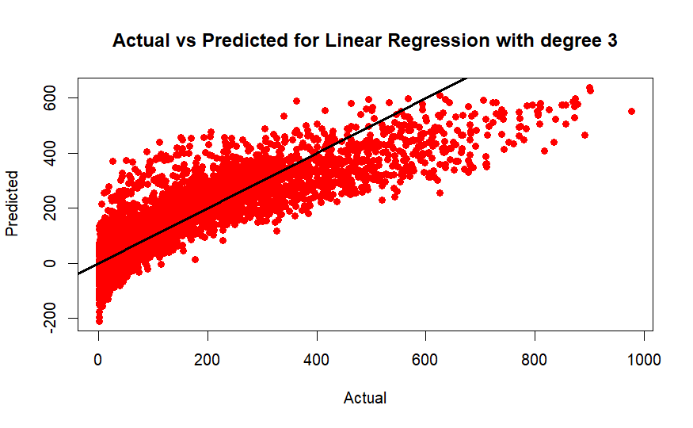

```r
predictions = predict(lm.fit_3,poly_de3[-trainIndex,])
plot(poly_de3[-trainIndex,]$cnt, predictions, pch = 16, col = "red", main = "Actual vs Predicted for Linear Regression with degree 3", xlab = "Actual", ylab = "Predicted")

abline(a = 0, b = 1, col = "black",lty=1,lwd=3)
```

```r
NA
NA
```

####Evaluation Metrics for Linear Regression Model of Polynomial of Degree 3

```r
actual_values <- poly_de3[-trainIndex,]$cnt
r_squared_lm3 <- 1 - sum((actual_values - predictions)^2) / sum((actual_values - mean(actual_values))^2)
mse_lm3 <- mean((actual_values - predictions)^2)
rmse_lm3 <- sqrt(mean((actual_values - predictions)^2))
mae_lm3 <- mean(abs(actual_values-predictions))

# Display the results
cat("R-squared: ", r_squared_lm3, "\n")
```

```
R-squared:  0.7011467
```

```r
cat("Mean Square Error (MsE): ", mse_lm3, "\n")
```

```
Mean Square Error (MsE):  9577.911
```

```r
cat("Root Mean Square Error (RMSE): ", rmse_lm3, "\n")
```

```
Root Mean Square Error (RMSE):  97.8668
```

```r
cat("Mean Average Error (MAE): ", mae_lm3, "\n")
```

```
Mean Average Error (MAE):  73.72196
```

## Linear Regression with Polynomial of Degree 4

Performed all numerical column with degree 4 and found whether exhibit multicolinearity or not

```r
predictors <- num_columns[-c(5)]
poly_de4 <- data.frame(cleaned_data)
for(predictor in predictors) {
  #poly_de2[paste(predictor, "de-2", sep = "-")] <- cleaned_data[predictor]^2
  poly_de4[[paste(predictor, "de-2", sep = "-")]] <- cleaned_data[[predictor]]^2
  poly_de4[[paste(predictor, "de-3", sep = "-")]] <- cleaned_data[[predictor]]^3
  poly_de4[[paste(predictor, "de-4", sep = "-")]] <- cleaned_data[[predictor]]^4
}
poly_de4 <- data.frame(poly_de4)
df04 <- model.matrix( ~., data = poly_de4)
df04 <- data.frame(df04[,-1])
lm_model00 <- lm(cnt ~., data = data.frame(df04))
aliases <- alias(lm_model00)
print(aliases)
```

```
Model :
cnt ~ season2 + season3 + season4 + yr1 + mnth2 + mnth3 + mnth4 +
    mnth5 + mnth6 + mnth7 + mnth8 + mnth9 + mnth10 + mnth11 +
    mnth12 + hr1 + hr2 + hr3 + hr4 + hr5 + hr6 + hr7 + hr8 +
    hr9 + hr10 + hr11 + hr12 + hr13 + hr14 + hr15 + hr16 + hr17 +
    hr18 + hr19 + hr20 + hr21 + hr22 + hr23 + holiday1 + weekday1 +
    weekday2 + weekday3 + weekday4 + weekday5 + weekday6 + weathersit2 +
    weathersit3 + weathersit4 + temp + atemp + hum + windspeed +
    temp.de.2 + temp.de.3 + temp.de.4 + atemp.de.2 + atemp.de.3 +
    atemp.de.4 + hum.de.2 + hum.de.3 + hum.de.4 + windspeed.de.2 +
    windspeed.de.3 + windspeed.de.4
```

```r
vif(lm(cnt ~., data = data.frame(df04)))
```

```
       season2        season3        season4            yr1          mnth2          mnth3          mnth4          mnth5
  7.550613e+00   1.075252e+01   7.448072e+00   1.054471e+00   1.937590e+00   2.747936e+00   5.695574e+00   6.614311e+00
         mnth6          mnth7          mnth8          mnth9         mnth10         mnth11         mnth12            hr1
  6.748172e+00   8.735687e+00   8.330137e+00   6.527369e+00   5.699590e+00   5.243573e+00   3.434855e+00   1.915516e+00
           hr2            hr3            hr4            hr5            hr6            hr7            hr8            hr9
  1.906727e+00   1.888074e+00   1.891631e+00   1.920779e+00   1.931054e+00   1.928819e+00   1.923142e+00   1.928365e+00
          hr10           hr11           hr12           hr13           hr14           hr15           hr16           hr17
  1.945971e+00   1.976288e+00   2.017242e+00   2.050492e+00   2.077247e+00   2.086891e+00   2.079904e+00   2.051777e+00
          hr18           hr19           hr20           hr21           hr22           hr23       holiday1       weekday1
  2.014320e+00   1.972950e+00   1.950329e+00   1.932988e+00   1.924557e+00   1.920937e+00   1.123225e+00   1.822528e+00
      weekday2       weekday3       weekday4       weekday5       weekday6    weathersit2    weathersit3    weathersit4
  1.719315e+00   1.728697e+00   1.730726e+00   1.734069e+00   1.723031e+00   1.206274e+00   1.423203e+00   1.005680e+00
          temp          atemp            hum      windspeed      temp.de.2      temp.de.3      temp.de.4     atemp.de.2
  6.670530e+03   6.806101e+03   1.591249e+03   5.749050e+01   8.198589e+04   1.176024e+05   1.883929e+04   8.018940e+04
    atemp.de.3     atemp.de.4       hum.de.2       hum.de.3       hum.de.4 windspeed.de.2 windspeed.de.3 windspeed.de.4
  1.103729e+05   1.698704e+04   2.214739e+04   3.597799e+04   6.528157e+03   6.875686e+02   1.163030e+03   2.402925e+02
```

```r
df000 <- df04[,-53]
scale_data <- scale(df000, center = apply(df000, 2, mean), scale = apply(df000, 2, sd))
cnt <- cleaned_data$cnt

scale_data <- data.frame(scale_data,cnt)
poly_de4 <- scale_data
lm.fit_4 <- train(cnt ~ ., data = poly_de4[trainIndex, ], method = "lm",  trControl = ctrl)

lm.summary_4 <- summary(lm.fit_4)
lm.summary_4
```

```
Call:
lm(formula = .outcome ~ ., data = dat)

Residuals:
    Min      1Q  Median      3Q     Max
-383.49  -60.90   -6.28   51.79  435.18

Coefficients:
                Estimate Std. Error t value Pr(>|t|)
(Intercept)     189.3241     0.8559 221.198  < 2e-16 ***
season2          16.4319     2.3566   6.973 3.25e-12 ***
season3          12.8813     2.8121   4.581 4.68e-06 ***
season4          30.1088     2.3426  12.853  < 2e-16 ***
yr1              43.0282     0.8787  48.968  < 2e-16 ***
mnth2             4.4427     1.1969   3.712 0.000207 ***
mnth3             8.7382     1.4265   6.126 9.28e-10 ***
mnth4             5.6604     2.0430   2.771 0.005602 **
mnth5             5.1804     2.2033   2.351 0.018725 *
mnth6            -0.6698     2.2253  -0.301 0.763434
mnth7            -3.3754     2.5376  -1.330 0.183493
mnth8            -0.2369     2.4788  -0.096 0.923876
mnth9             8.0716     2.1912   3.684 0.000231 ***
mnth10            6.2610     2.0421   3.066 0.002173 **
mnth11            1.9710     1.9593   1.006 0.314437
mnth12            1.7487     1.5912   1.099 0.271773
hr1              -3.1044     1.1756  -2.641 0.008281 **
hr2              -5.1521     1.1931  -4.318 1.58e-05 ***
hr3              -6.6077     1.1690  -5.653 1.61e-08 ***
hr4              -7.7860     1.1812  -6.592 4.50e-11 ***
hr5              -4.0057     1.1909  -3.364 0.000772 ***
hr6               7.3622     1.1933   6.170 7.03e-10 ***
hr7              33.9095     1.1985  28.294  < 2e-16 ***
hr8              62.0207     1.1809  52.521  < 2e-16 ***
hr9              32.3601     1.1880  27.238  < 2e-16 ***
hr10             21.2439     1.1931  17.806  < 2e-16 ***
hr11             27.0356     1.2103  22.337  < 2e-16 ***
hr12             35.0654     1.2190  28.766  < 2e-16 ***
hr13             34.1375     1.2251  27.866  < 2e-16 ***
hr14             30.9485     1.2412  24.934  < 2e-16 ***
hr15             33.2248     1.2272  27.074  < 2e-16 ***
```

[output cut: 25 more lines]

```
atemp.de.2      132.3729   244.2543   0.542 0.587864
atemp.de.3     -172.0679   285.2908  -0.603 0.546431
atemp.de.4       23.4710   111.6663   0.210 0.833523
hum.de.2        114.0380   126.5634   0.901 0.367586
hum.de.3       -275.2557   161.4129  -1.705 0.088163 .
hum.de.4        150.6494    68.7698   2.191 0.028495 *
windspeed.de.2    7.2766    23.3483   0.312 0.755307
windspeed.de.3  -24.7760    30.9486  -0.801 0.423405
windspeed.de.4    9.8170    14.3730   0.683 0.494607
---
Signif. codes:  0 ‘***’ 0.001 ‘**’ 0.01 ‘*’ 0.05 ‘.’ 0.1 ‘ ’ 1

Residual standard error: 100.9 on 13837 degrees of freedom
Multiple R-squared:  0.6942,    Adjusted R-squared:  0.6928
F-statistic: 490.9 on 64 and 13837 DF,  p-value: < 2.2e-16
```

####Plotted the Actual Values Vs Predicted Values

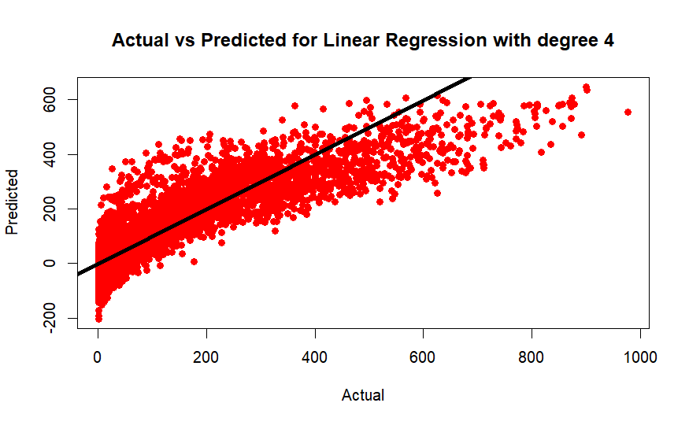

```r
predictions = predict(lm.fit_4,poly_de4[-trainIndex,])
plot(poly_de4[-trainIndex,]$cnt, predictions, pch = 16, col = "red", main = "Actual vs Predicted for Linear Regression with degree 4", xlab = "Actual", ylab = "Predicted")

abline(a = 0, b = 1, col = "black",lty=1,lwd=4)
```

```r
NA
NA
```

####Evaluation Metrics for Linear Regression Model of Polynomial of Degree 4

```r
actual_values <- poly_de4[-trainIndex,]$cnt
r_squared_lm4 <- 1 - sum((actual_values - predictions)^2) / sum((actual_values - mean(actual_values))^2)
mse_lm4 <- mean((actual_values - predictions)^2)
rmse_lm4 <- sqrt(mean((actual_values - predictions)^2))
mae_lm4 <- mean(abs(actual_values-predictions))
cat("Mean Average Error (MAE): ", mae_lm4, "\n")
```

```
Mean Average Error (MAE):  73.43218
```

```r
# Display the results
cat("R-squared: ", r_squared_lm4, "\n")
```

```
R-squared:  0.7031851
```

```r
cat("Mean Square Error (MsE): ", mse_lm4, "\n")
```

```
Mean Square Error (MsE):  9512.586
```

```r
cat("Root Mean Square Error (RMSE): ", rmse_lm4, "\n")
```

```
Root Mean Square Error (RMSE):  97.53249
```

```r
cat("Mean Average Error (MAE): ", mae_lm4, "\n")
```

```
Mean Average Error (MAE):  73.43218
```

# SubSet Selection

## Forward Subset Selection

```r
regfit.fwd=regsubsets(cnt ~ ., data=dff[trainIndex,],nvmax=ncol(dff)-1,method="forward")
reg.summary.fwd <- summary(regfit.fwd)
reg.summary.fwd
```

```
Subset selection object
Call: regsubsets.formula(cnt ~ ., data = dff[trainIndex, ], nvmax = ncol(dff) -
    1, method = "forward")
52 Variables  (and intercept)
            Forced in Forced out
season2         FALSE      FALSE
season3         FALSE      FALSE
season4         FALSE      FALSE
yr1             FALSE      FALSE
mnth2           FALSE      FALSE
mnth3           FALSE      FALSE
mnth4           FALSE      FALSE
mnth5           FALSE      FALSE
mnth6           FALSE      FALSE
mnth7           FALSE      FALSE
mnth8           FALSE      FALSE
mnth9           FALSE      FALSE
mnth10          FALSE      FALSE
mnth11          FALSE      FALSE
mnth12          FALSE      FALSE
hr1             FALSE      FALSE
hr2             FALSE      FALSE
hr3             FALSE      FALSE
hr4             FALSE      FALSE
hr5             FALSE      FALSE
hr6             FALSE      FALSE
hr7             FALSE      FALSE
hr8             FALSE      FALSE
hr9             FALSE      FALSE
hr10            FALSE      FALSE
hr11            FALSE      FALSE
hr12            FALSE      FALSE
hr13            FALSE      FALSE
hr14            FALSE      FALSE
hr15            FALSE      FALSE
hr16            FALSE      FALSE
hr17            FALSE      FALSE
hr18            FALSE      FALSE
hr19            FALSE      FALSE
hr20            FALSE      FALSE
```

[output cut: 85 more lines]

```
6  ( 1 )  " "
7  ( 1 )  " "
8  ( 1 )  " "
9  ( 1 )  " "
10  ( 1 ) " "
11  ( 1 ) " "
12  ( 1 ) " "
13  ( 1 ) " "
14  ( 1 ) " "
15  ( 1 ) " "
16  ( 1 ) " "
17  ( 1 ) " "
18  ( 1 ) " "
19  ( 1 ) " "
 [ reached getOption("max.print") -- omitted 33 rows ]
```

#### Finding the R2, MSE and MAE

```r
cv.errors.fwd <- rep(NA,51)
mae.fwd <- rep(NA,51)
cv.r2.fwd <- rep(NA,51)
test.mat=model.matrix(cnt~.,data=dff[-trainIndex,])

best.fit.fwd <- regsubsets(cnt ~., data = dff[trainIndex,], nvmax = ncol(dff)-1,method = "forward")
for (i in 1:51) {

  coefi=coef(best.fit.fwd,id=i)
  pred=test.mat[,names(coefi)]%*%coefi
  cv.errors.fwd[i]=mean((dff$cnt[-trainIndex]-pred)^2)
  cv.r2.fwd[i] = 1 - sum((pred-dff$cnt[-trainIndex])^2) / sum((dff$cnt[-trainIndex] - mean(dff$cnt[-trainIndex]))^2)
  mae.fwd[i] <- mean(abs(dff$cnt[-trainIndex]-pred))
}
rmse_fwd <- sqrt(cv.errors.fwd)
cv.errors.fwd
```

```
 [1] 26444.648 24318.891 22022.468 20428.590 18292.142 16597.379 15734.361 15044.118 14638.365 14045.652 13643.904
[12] 13355.286 12989.082 12584.272 12214.863 11711.843 11519.840 11342.025 11218.695 11078.790 11015.072 10923.049
[23] 10823.611 10693.821 10637.727 10504.583 10406.582 10334.992 10174.868 10083.815 10045.140 10028.980 10016.478
[34]  9966.989  9956.881  9923.796  9925.677  9905.524  9901.974  9875.581  9858.089  9846.435  9848.432  9837.912
[45]  9837.510  9834.092  9837.029  9842.000  9839.138  9839.497  9840.846
```

```r
rmse_fwd
```

```
 [1] 162.61811 155.94515 148.39969 142.92862 135.24845 128.83082 125.43668 122.65447 120.98911 118.51435 116.80712
[12] 115.56507 113.96965 112.17964 110.52087 108.22127 107.33052 106.49894 105.91834 105.25583 104.95271 104.51339
[23] 104.03658 103.41093 103.13936 102.49187 102.01265 101.66116 100.87055 100.41820 100.22545 100.14479 100.08235
[34]  99.83481  99.78417  99.61825  99.62769  99.52650  99.50866  99.37596  99.28791  99.22920  99.23927  99.18625
[45]  99.18422  99.16699  99.18180  99.20685  99.19243  99.19424  99.20104
```

```r
cv.r2.fwd
```

```
 [1] 0.1748651 0.2411937 0.3128474 0.3625802 0.4292423 0.4821229 0.5090511 0.5305883 0.5432487 0.5617428 0.5742782
[12] 0.5832838 0.5947102 0.6073413 0.6188677 0.6345631 0.6405540 0.6461023 0.6499504 0.6543158 0.6563040 0.6591753
[23] 0.6622780 0.6663277 0.6680780 0.6722324 0.6752903 0.6775241 0.6825203 0.6853614 0.6865681 0.6870724 0.6874624
[34] 0.6890066 0.6893220 0.6903543 0.6902956 0.6909245 0.6910352 0.6918587 0.6924045 0.6927682 0.6927059 0.6930341
[45] 0.6930467 0.6931533 0.6930617 0.6929066 0.6929959 0.6929847 0.6929426
```

```r
mae.fwd
```

```
 [1] 123.01731 118.34029 113.06684 109.99057 102.86169  99.10362  96.00380  94.37996  92.70810  90.97521  88.96175
[12]  87.54493  85.84824  83.93152  82.47349  80.21918  79.48121  78.75375  78.19134  77.88094  77.56691  77.38814
[23]  77.27484  76.24879  76.16018  76.18257  76.20981  75.59030  75.27805  74.70703  74.56752  74.42959  74.53825
[34]  74.41270  74.35787  74.27927  74.33013  74.24202  74.24936  74.14035  74.06393  73.96744  73.99364  73.93869
[45]  73.99662  74.07028  74.08273  74.11361  74.14348  74.14430  74.15787
```

```r
which.min(reg.summary.fwd$bic)
```

```
[1] 38
```

#### Plot the curve with BIC with number of Variables

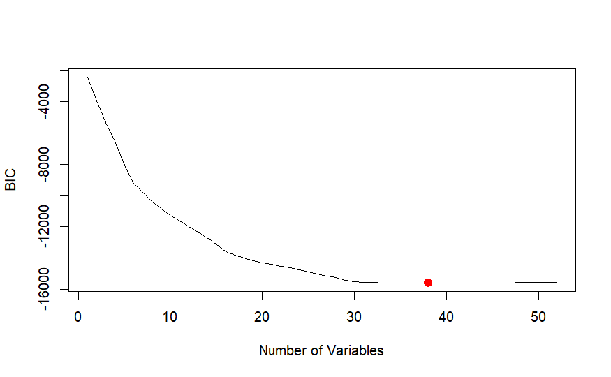

```r
plot(reg.summary.fwd$bic,xlab="Number of Variables",ylab="BIC",type='l')
points(38,reg.summary.fwd$bic[38],col="red",cex=2,pch=20)
```

#### Plotting the BIC with variables

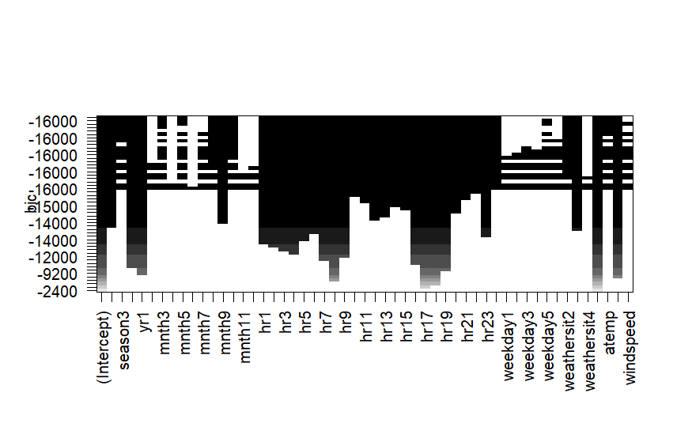

```r
plot(regfit.fwd,scale="bic")
```

```r
coef(regfit.fwd,38)
```

```
(Intercept)     season2     season3     season4         yr1       mnth3       mnth5       mnth8       mnth9      mnth10
 189.288952   18.747791   10.223475   25.909799   42.103023    3.584787    3.924685    4.702713   11.367324    5.544430
        hr1         hr2         hr3         hr4         hr5         hr6         hr7         hr8         hr9        hr10
  -3.209394   -5.243933   -6.922451   -8.122287   -4.202379    7.272126   34.115324   62.272467   32.447657   21.261054
       hr11        hr12        hr13        hr14        hr15        hr16        hr17        hr18        hr19        hr20
  26.891246   34.650584   33.425537   30.280654   32.611738   44.998609   76.803306   68.946476   46.829041   31.178625
       hr21        hr22        hr23    holiday1 weathersit2 weathersit3        temp       atemp         hum
  21.679811   14.347000    6.588060   -4.361285   -4.638782  -18.646796   24.600633   19.841455  -15.254342
```

```r
coefi=coef(best.fit.fwd,id=38)
coefi
```

```
(Intercept)     season2     season3     season4         yr1       mnth3       mnth5       mnth8       mnth9      mnth10
 189.288952   18.747791   10.223475   25.909799   42.103023    3.584787    3.924685    4.702713   11.367324    5.544430
        hr1         hr2         hr3         hr4         hr5         hr6         hr7         hr8         hr9        hr10
  -3.209394   -5.243933   -6.922451   -8.122287   -4.202379    7.272126   34.115324   62.272467   32.447657   21.261054
       hr11        hr12        hr13        hr14        hr15        hr16        hr17        hr18        hr19        hr20
  26.891246   34.650584   33.425537   30.280654   32.611738   44.998609   76.803306   68.946476   46.829041   31.178625
       hr21        hr22        hr23    holiday1 weathersit2 weathersit3        temp       atemp         hum
  21.679811   14.347000    6.588060   -4.361285   -4.638782  -18.646796   24.600633   19.841455  -15.254342
```

```r
pred.fwd=test.mat[,names(coefi)]%*%coefi
```

####Plotted the Actual Values Vs Predicted Values

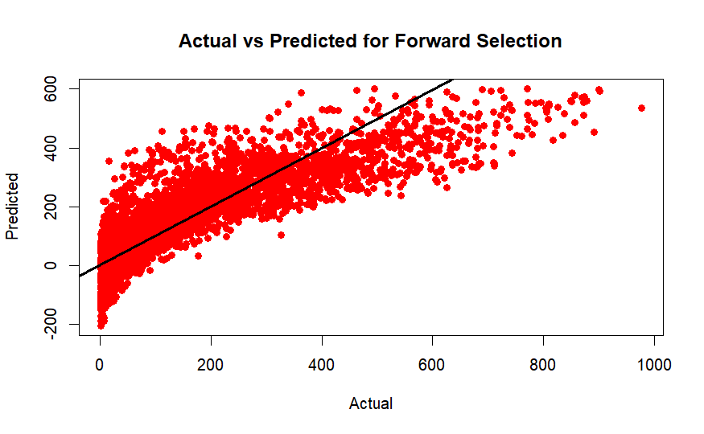

```r
plot(dff$cnt[-trainIndex], pred.fwd, pch = 16, col = "red", main = "Actual vs Predicted for Forward Selection", xlab = "Actual", ylab = "Predicted")
abline(a = 0, b = 1, col = "black",lty=1,lwd=3)
```

####Evaluation Metrics for Forward Selection

```r
mse_fw <- cv.errors.fwd[38]
rmse_fw <-rmse_fwd[38]
r_squared_fw<-cv.r2.fwd[38]
mae_fw <- mae.fwd[38]
# Display the results
cat("R-squared: ", r_squared_fw, "\n")
```

```
R-squared:  0.6909245
```

```r
cat("Mean Square Error (MsE): ", mse_fw, "\n")
```

```
Mean Square Error (MsE):  9905.524
```

```r
cat("Root Mean Square Error (RMSE): ", rmse_fw, "\n")
```

```
Root Mean Square Error (RMSE):  99.5265
```

```r
cat("Mean Average Error (MAE): ", mae_fw, "\n")
```

```
Mean Average Error (MAE):  74.24202
```

## Backward Subset Selection

```r
################ Backward

regfit.bwd=regsubsets(cnt ~ ., data=dff[trainIndex,],nvmax=ncol(dff)-1,method="backward")
reg.summary.bwd <- summary(regfit.bwd)
reg.summary.bwd
```

```
Subset selection object
Call: regsubsets.formula(cnt ~ ., data = dff[trainIndex, ], nvmax = ncol(dff) -
    1, method = "backward")
52 Variables  (and intercept)
            Forced in Forced out
season2         FALSE      FALSE
season3         FALSE      FALSE
season4         FALSE      FALSE
yr1             FALSE      FALSE
mnth2           FALSE      FALSE
mnth3           FALSE      FALSE
mnth4           FALSE      FALSE
mnth5           FALSE      FALSE
mnth6           FALSE      FALSE
mnth7           FALSE      FALSE
mnth8           FALSE      FALSE
mnth9           FALSE      FALSE
mnth10          FALSE      FALSE
mnth11          FALSE      FALSE
mnth12          FALSE      FALSE
hr1             FALSE      FALSE
hr2             FALSE      FALSE
hr3             FALSE      FALSE
hr4             FALSE      FALSE
hr5             FALSE      FALSE
hr6             FALSE      FALSE
hr7             FALSE      FALSE
hr8             FALSE      FALSE
hr9             FALSE      FALSE
hr10            FALSE      FALSE
hr11            FALSE      FALSE
hr12            FALSE      FALSE
hr13            FALSE      FALSE
hr14            FALSE      FALSE
hr15            FALSE      FALSE
hr16            FALSE      FALSE
hr17            FALSE      FALSE
hr18            FALSE      FALSE
hr19            FALSE      FALSE
hr20            FALSE      FALSE
```

[output cut: 85 more lines]

```
6  ( 1 )  " "
7  ( 1 )  " "
8  ( 1 )  " "
9  ( 1 )  " "
10  ( 1 ) " "
11  ( 1 ) " "
12  ( 1 ) " "
13  ( 1 ) " "
14  ( 1 ) " "
15  ( 1 ) " "
16  ( 1 ) " "
17  ( 1 ) " "
18  ( 1 ) " "
19  ( 1 ) " "
 [ reached getOption("max.print") -- omitted 33 rows ]
```

#### Finding the R2, MSE and MAE

```r
cv.errors.bwd <- rep(NA,51)
cv.r2.bwd <- rep(NA,51)
mae.bwd <- rep(NA,51)
test.mat=model.matrix(cnt~.,data=dff[-trainIndex,])

best.fit.bwd <- regsubsets(cnt ~., data = dff[trainIndex,], nvmax = ncol(dff)-1,method = "backward")
for (i in 1:51) {

  coefi=coef(best.fit.bwd,id=i)
  pred=test.mat[,names(coefi)]%*%coefi
  cv.errors.bwd[i]=mean((dff$cnt[-trainIndex]-pred)^2)
  mae.bwd[i] <- mean(abs(dff$cnt[-trainIndex]-pred))
  cv.r2.bwd[i] = 1 - sum((pred-dff$cnt[-trainIndex])^2) / sum((dff$cnt[-trainIndex] - mean(dff$cnt[-trainIndex]))^2)
}

rmse_bwd <- sqrt(cv.errors.bwd)
cv.errors.bwd
```

```
 [1] 26444.648 24318.891 22022.468 20428.590 18488.851 17397.522 16699.877 16275.440 15902.588 15602.269 15092.865
[12] 14563.414 13947.860 13212.865 12677.919 12256.154 11730.837 11316.816 10918.783 10667.190 10517.273 10385.000
[23] 10290.135 10184.860 10119.078 10081.399 10064.493 10056.063 10018.403 10018.208  9991.928  9986.486  9970.173
[34]  9934.566  9918.827  9918.969  9915.277  9903.889  9905.291  9893.876  9892.542  9890.012  9888.841  9878.748
[45]  9869.655  9844.325  9844.702  9836.636  9838.494  9839.497  9840.846
```

```r
rmse_bwd
```

```
 [1] 162.61811 155.94515 148.39969 142.92862 135.97372 131.89967 129.22801 127.57523 126.10547 124.90904 122.85302
[12] 120.67897 118.10106 114.94723 112.59626 110.70751 108.30899 106.38053 104.49298 103.28209 102.55376 101.90682
[23] 101.44031 100.92007 100.59363 100.40617 100.32195 100.27992 100.09197 100.09100  99.95963  99.93241  99.85075
[34]  99.67229  99.59331  99.59402  99.57548  99.51828  99.52533  99.46797  99.46126  99.44854  99.44265  99.39189
[45]  99.34614  99.21857  99.22047  99.17982  99.18918  99.19424  99.20104
```

```r
cv.r2.bwd
```

```
 [1] 0.1748651 0.2411937 0.3128474 0.3625802 0.4231046 0.4571566 0.4789247 0.4921682 0.5038020 0.5131727 0.5290673
[12] 0.5455874 0.5647941 0.5877277 0.6044193 0.6175793 0.6339704 0.6468888 0.6593084 0.6671587 0.6718365 0.6759637
[23] 0.6789237 0.6822085 0.6842611 0.6854368 0.6859643 0.6862273 0.6874024 0.6874084 0.6882285 0.6883982 0.6889073
[34] 0.6900183 0.6905094 0.6905049 0.6906202 0.6909755 0.6909317 0.6912879 0.6913295 0.6914085 0.6914450 0.6917599
[45] 0.6920436 0.6928340 0.6928222 0.6930739 0.6930160 0.6929847 0.6929426
```

```r
mae.bwd
```

```
 [1] 123.01731 118.34029 113.06684 109.99057 105.60089 102.25691  99.99493  98.94756  98.19143  97.38337  96.06362
[12]  93.47489  90.62014  88.83748  87.09852  84.50215  82.40453  81.13461  79.88324  78.07976  77.26626  76.87274
[23]  75.99495  75.15819  74.91929  74.79138  74.65781  74.63927  74.59591  74.59946  74.55152  74.61829  74.51184
[34]  74.40798  74.32336  74.36977  74.39076  74.27061  74.29093  74.24538  74.30069  74.38561  74.40405  74.32844
[45]  74.28051  74.17268  74.17313  74.12747  74.14691  74.14430  74.15787
```

```r
which.min(reg.summary.bwd$bic)
```

```
[1] 37
```

####plotting the BIC with number of variables

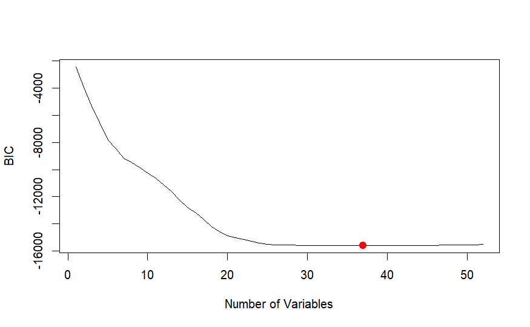

```r
plot(reg.summary.bwd$bic,xlab="Number of Variables",ylab="BIC",type='l')
points(37,reg.summary.bwd$bic[37],col="red",cex=2,pch=20)
```

####plotting the BIC with variables

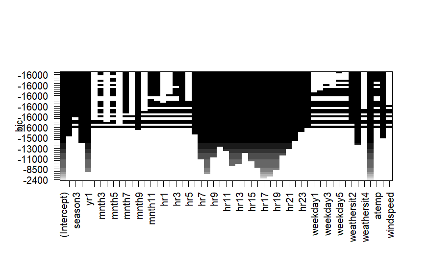

```r
plot(regfit.bwd,scale="bic")
```

```r
coef(regfit.bwd,37)
```

```
(Intercept)     season2     season3     season4         yr1       mnth3       mnth5       mnth7       mnth9      mnth11
 189.317582   17.584018   15.766679   32.556086   42.112138    3.199621    3.797830   -5.654286    6.706030   -5.173637
     mnth12         hr3         hr4         hr6         hr7         hr8         hr9        hr10        hr11        hr12
  -4.294374   -3.845592   -5.030205   10.426011   37.263692   65.419296   35.585858   24.436385   30.109443   37.829213
       hr13        hr14        hr15        hr16        hr17        hr18        hr19        hr20        hr21        hr22
  36.632026   33.459930   35.764685   48.183632   79.970277   72.138709   50.008978   34.373102   24.846127   17.520361
       hr23    holiday1    weekday5 weathersit2 weathersit3        temp       atemp         hum
   9.740716   -4.093087    2.727488   -4.680667  -18.609953   23.802747   21.206119  -14.910452
```

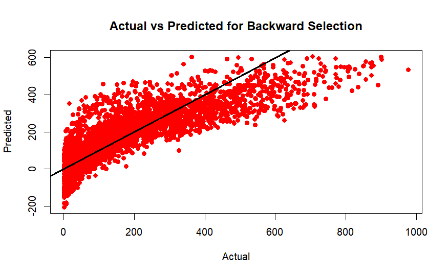

```r
coefi=coef(best.fit.bwd,id=37)
pred.bwd=test.mat[,names(coefi)]%*%coefi
plot(dff$cnt[-trainIndex], pred.bwd, pch = 16, col = "red", main = "Actual vs Predicted for Backward Selection", xlab = "Actual", ylab = "Predicted")
abline(a = 0, b = 1, col = "black",lty=1,lwd=3)
```

####Evaluation Metrics for Backward Selection

```r
mse_bw <- cv.errors.bwd[37]
rmse_bw <-rmse_bwd[37]
r_squared_bw<-cv.r2.bwd[37]
mae_bw <- mae.bwd[37]
# Display the results
cat("R-squared: ", r_squared_bw, "\n")
```

```
R-squared:  0.6906202
```

```r
cat("Mean Square Error (MsE): ", mse_bw, "\n")
```

```
Mean Square Error (MsE):  9915.277
```

```r
cat("Root Mean Square Error (RMSE): ", rmse_bw, "\n")
```

```
Root Mean Square Error (RMSE):  99.57548
```

```r
cat("Mean Absolute Error (RMSE): ", mae_bw, "\n")
```

```
Mean Absolute Error (RMSE):  74.39076
```

```r
X <- model.matrix(cnt~.,dff)[,-1]
y <- dff$cnt
```

## Lasso Regression

performed lasso Regression with 5 fold validation

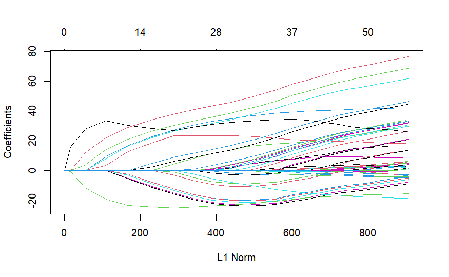

```r
grid=10^seq(10,-2,length=100)
lasso.mod=glmnet(X[trainIndex,],y[trainIndex],alpha=1,lambda=grid,nfolds=5)
plot(lasso.mod)
```

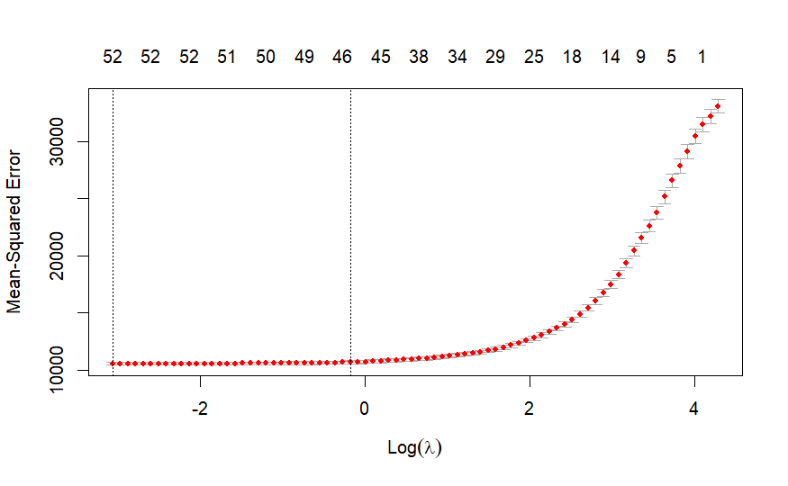

```r
set.seed(1)
cv.out.lasso=cv.glmnet(X[trainIndex,],y[trainIndex],alpha=1,nfolds=5)
plot(cv.out.lasso)
```

##### Best Lambda Value

```r
bestlam=cv.out.lasso$lambda.min
bestlam
```

```
[1] 0.04696182
```

#### Evaluatrion Metrics

```r
lasso.pred=predict(lasso.mod,s=bestlam,newx=X[-trainIndex,])
mse_lr <- mean((lasso.pred-y[-trainIndex])^2)
mae_lr <- mean(abs(lasso.pred-y[-trainIndex]))
rmse_lr <- sqrt(mse_lr)
r_squared_lr <- 1 - sum((lasso.pred-y[-trainIndex])^2) / sum((y[-trainIndex] - mean(y[-trainIndex]))^2)
```

#### Plotting the Actual values Vs Predicted vaues

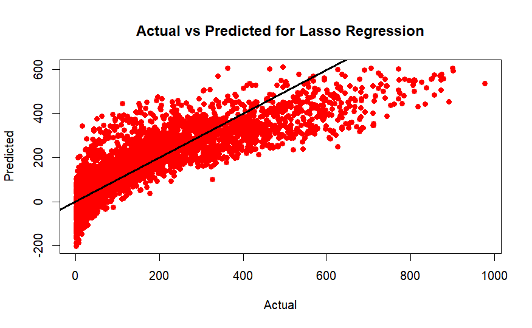

```r
plot(dff$cnt[-trainIndex], lasso.pred, pch = 16, col = "red", main = "Actual vs Predicted for Lasso Regression", xlab = "Actual", ylab = "Predicted")
abline(a = 0, b = 1, col = "black",lty=1,lwd=3)
```

```r
NA
NA
```

#### To get good predictors using Lasso

```r
out=glmnet(X,y,alpha=1,lambda=grid)
lasso.coef=predict(out,type="coefficients",s=bestlam)[1:ncol(X),]
lasso.coef
```

```
(Intercept)     season2     season3     season4         yr1       mnth2       mnth3       mnth4       mnth5       mnth6
189.4839155  16.8577497  13.6403741  28.6140927  42.6070787   0.5347265   3.4018016   0.9128913   4.8143983   0.7602159
      mnth7       mnth8       mnth9      mnth10      mnth11      mnth12         hr1         hr2         hr3         hr4
 -4.4177021   1.4885979   8.3489765   4.1107508  -2.7242267  -1.8195189  -4.3940038  -6.1581060  -8.1785361  -8.7635333
        hr5         hr6         hr7         hr8         hr9        hr10        hr11        hr12        hr13        hr14
 -5.5658046   6.0917871  33.1206990  61.2071903  31.6025486  20.6256687  25.6801461  33.5438328  32.5368973  29.3447323
       hr15        hr16        hr17        hr18        hr19        hr20        hr21        hr22        hr23    holiday1
 31.2373667  43.7272945  74.5796167  68.1020591  46.3611803  30.4328204  20.5480397  13.1663565   5.4087410  -4.3636285
   weekday1    weekday2    weekday3    weekday4    weekday5    weekday6 weathersit2 weathersit3 weathersit4        temp
  2.8973294   3.4436240   4.4173193   4.2494181   5.7814294   5.3450470  -4.4654339 -17.6923249  -0.7710976  23.3011725
      atemp         hum
 22.0968532 -16.1323388
```

```r
lasso.coef[lasso.coef!=0]
```

```
(Intercept)     season2     season3     season4         yr1       mnth2       mnth3       mnth4       mnth5       mnth6
189.4839155  16.8577497  13.6403741  28.6140927  42.6070787   0.5347265   3.4018016   0.9128913   4.8143983   0.7602159
      mnth7       mnth8       mnth9      mnth10      mnth11      mnth12         hr1         hr2         hr3         hr4
 -4.4177021   1.4885979   8.3489765   4.1107508  -2.7242267  -1.8195189  -4.3940038  -6.1581060  -8.1785361  -8.7635333
        hr5         hr6         hr7         hr8         hr9        hr10        hr11        hr12        hr13        hr14
 -5.5658046   6.0917871  33.1206990  61.2071903  31.6025486  20.6256687  25.6801461  33.5438328  32.5368973  29.3447323
       hr15        hr16        hr17        hr18        hr19        hr20        hr21        hr22        hr23    holiday1
 31.2373667  43.7272945  74.5796167  68.1020591  46.3611803  30.4328204  20.5480397  13.1663565   5.4087410  -4.3636285
   weekday1    weekday2    weekday3    weekday4    weekday5    weekday6 weathersit2 weathersit3 weathersit4        temp
  2.8973294   3.4436240   4.4173193   4.2494181   5.7814294   5.3450470  -4.4654339 -17.6923249  -0.7710976  23.3011725
      atemp         hum
 22.0968532 -16.1323388
```

```r
# Display the results
cat("R-squared: ", r_squared_lr, "\n")
```

```
R-squared:  0.6929642
```

```r
cat("Mean Square Error (MsE): ", mse_lr, "\n")
```

```
Mean Square Error (MsE):  9840.154
```

```r
cat("Mean Absolute Error (MAE): ", mae_lr, "\n")
```

```
Mean Absolute Error (MAE):  74.09753
```

```r
cat("Root Mean Square Error (RMSE): ", rmse_lr, "\n")
```

```
Root Mean Square Error (RMSE):  99.19755
```

## Ridge Regression

Perfoming the Ridge Regression with 5 fold validation

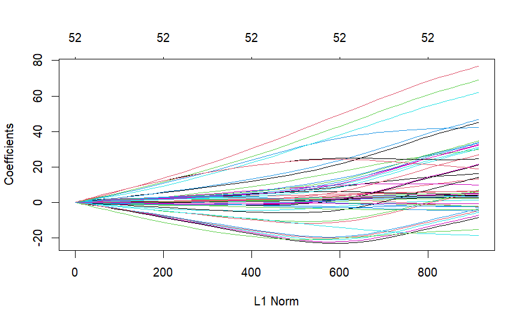

```r
ridge.mod=glmnet(X[trainIndex,],y[trainIndex],alpha=0,lambda=grid,nfold = 5)
plot(ridge.mod)
```

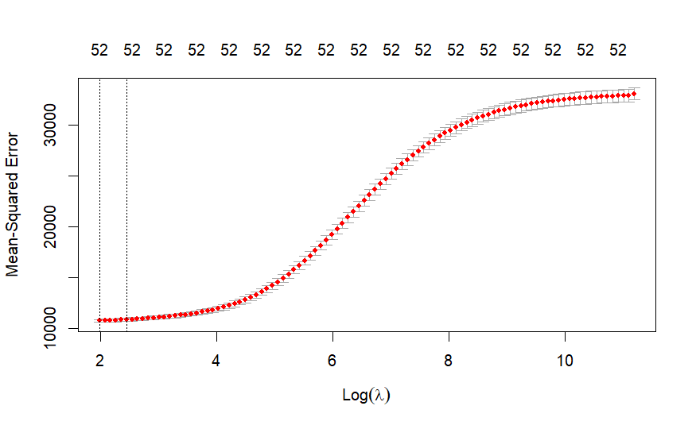

```r
set.seed(1)
cv.out.ridge=cv.glmnet(X[trainIndex,],y[trainIndex],alpha=0,nfold = 5)
plot(cv.out.ridge)
```

##### Best Lambda Value

```r
bestlam=cv.out.ridge$lambda.min
bestlam
```

```
[1] 7.305738
```

#### Evaluation Metrics

```r
ridge.pred=predict(ridge.mod,s=bestlam,newx=X[-trainIndex,])
mse_rr <- mean((ridge.pred-y[-trainIndex])^2)
mae_rr <- mean(abs(ridge.pred-y[-trainIndex]))
rmse_rr <- sqrt(mse_rr)
r_squared_rr <- 1 - sum((ridge.pred-y[-trainIndex])^2) / sum((y[-trainIndex] - mean(y[-trainIndex]))^2)
```

#### Plotting the Actual values Vs Predicted vaues

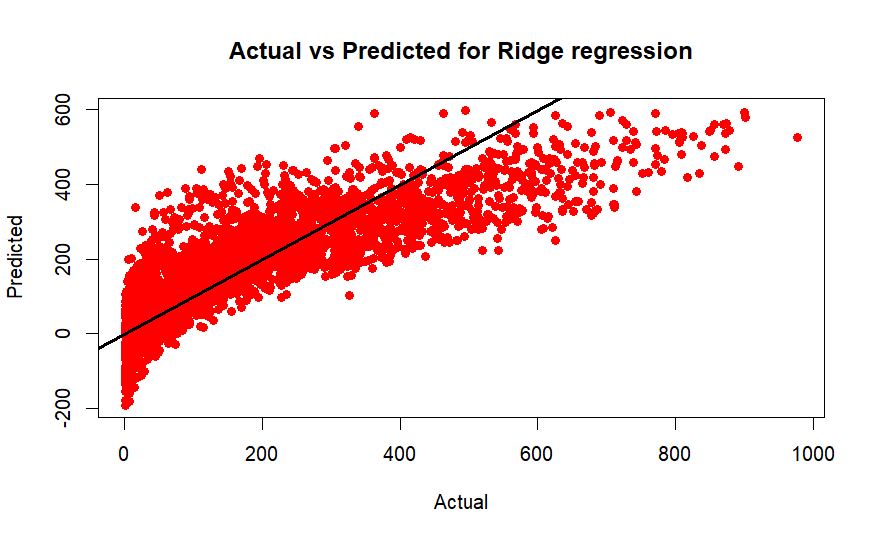

```r
plot(dff$cnt[-trainIndex], ridge.pred, pch = 16, col = "red", main = "Actual vs Predicted for Ridge regression", xlab = "Actual", ylab = "Predicted")
abline(a = 0, b = 1, col = "black",lty=1,lwd=3)
```

#### To get good predictors using Ridge

```r
out=glmnet(X,y,alpha=0,lambda=grid)
ridge.coef=predict(out,type="coefficients",s=bestlam)[1:ncol(X),]
ridge.coef
```

```
(Intercept)     season2     season3     season4         yr1       mnth2       mnth3       mnth4       mnth5       mnth6
189.4839155  12.5550578   7.7016991  22.8651171  40.6945589  -0.4186437   2.9264633   1.8598086   5.6008711   1.4196220
      mnth7       mnth8       mnth9      mnth10      mnth11      mnth12         hr1         hr2         hr3         hr4
 -3.1470141   2.9491512   9.9927804   6.2129840  -0.1525871  -0.2738258 -14.8754593 -16.4521741 -18.2137968 -18.7318176
        hr5         hr6         hr7         hr8         hr9        hr10        hr11        hr12        hr13        hr14
-15.7770654  -4.5358967  21.3845958  48.3075871  19.6213550   8.8735587  13.5712367  20.9766971  19.8998662  16.7523456
       hr15        hr16        hr17        hr18        hr19        hr20        hr21        hr22        hr23    holiday1
 18.5526797  30.5976738  60.3741305  54.2571669  33.4940456  18.2856256   8.9042161   1.8890558  -5.5148611  -4.4042221
   weekday1    weekday2    weekday3    weekday4    weekday5    weekday6 weathersit2 weathersit3 weathersit4        temp
  2.3121205   2.8247142   3.7550335   3.5338167   5.0127536   4.6124441  -3.4852771 -15.9546090  -0.6671070  24.2334388
      atemp         hum
 23.9738209 -18.6403522
```

```r
ridge.coef[ridge.coef!=0]
```

```
(Intercept)     season2     season3     season4         yr1       mnth2       mnth3       mnth4       mnth5       mnth6
189.4839155  12.5550578   7.7016991  22.8651171  40.6945589  -0.4186437   2.9264633   1.8598086   5.6008711   1.4196220
      mnth7       mnth8       mnth9      mnth10      mnth11      mnth12         hr1         hr2         hr3         hr4
 -3.1470141   2.9491512   9.9927804   6.2129840  -0.1525871  -0.2738258 -14.8754593 -16.4521741 -18.2137968 -18.7318176
        hr5         hr6         hr7         hr8         hr9        hr10        hr11        hr12        hr13        hr14
-15.7770654  -4.5358967  21.3845958  48.3075871  19.6213550   8.8735587  13.5712367  20.9766971  19.8998662  16.7523456
       hr15        hr16        hr17        hr18        hr19        hr20        hr21        hr22        hr23    holiday1
 18.5526797  30.5976738  60.3741305  54.2571669  33.4940456  18.2856256   8.9042161   1.8890558  -5.5148611  -4.4042221
   weekday1    weekday2    weekday3    weekday4    weekday5    weekday6 weathersit2 weathersit3 weathersit4        temp
  2.3121205   2.8247142   3.7550335   3.5338167   5.0127536   4.6124441  -3.4852771 -15.9546090  -0.6671070  24.2334388
      atemp         hum
 23.9738209 -18.6403522
```

```r
# Display the results
cat("R-squared: ", r_squared_rr, "\n")
```

```
R-squared:  0.6877307
```

```r
cat("Mean Square Error (MSE): ", mse_rr, "\n")
```

```
Mean Square Error (MSE):  10007.88
```

```r
cat("Root Mean Square Error (RMSE): ", rmse_rr, "\n")
```

```
Root Mean Square Error (RMSE):  100.0394
```

```r
cat("Mean Absolute Error (MAE): ", mae_rr, "\n")
```

```
Mean Absolute Error (MAE):  74.38064
```

## Random Forest

```r
#library(reprtree)
set.seed(1)
rf.model=randomForest(cnt~.,data=dff,subset=trainIndex,importance=TRUE)
```

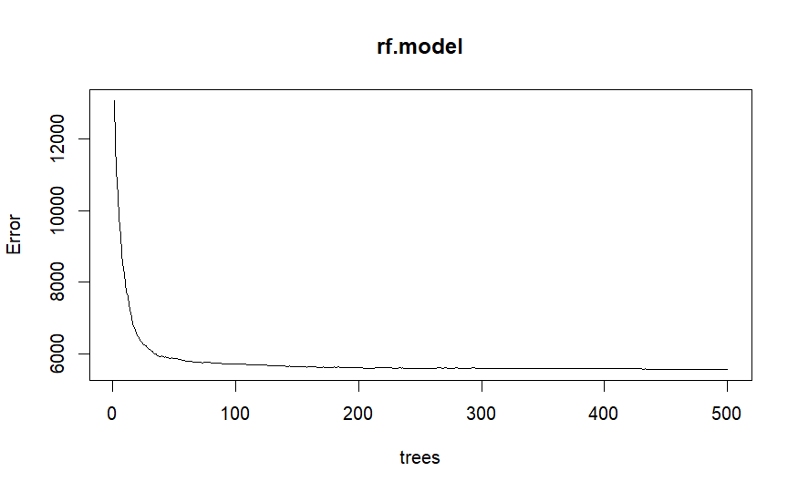

```r
plot(rf.model)
```

#### Summary of the Model

```r
rf.summary <- summary(rf.model)
rf.summary
```

```
                Length Class  Mode
call                5  -none- call
type                1  -none- character
predicted       13902  -none- numeric
mse               500  -none- numeric
rsq               500  -none- numeric
oob.times       13902  -none- numeric
importance        104  -none- numeric
importanceSD       52  -none- numeric
localImportance     0  -none- NULL
proximity           0  -none- NULL
ntree               1  -none- numeric
mtry                1  -none- numeric
forest             11  -none- list
coefs               0  -none- NULL
y               13902  -none- numeric
test                0  -none- NULL
inbag               0  -none- NULL
terms               3  terms  call
```

#### Evaluation Metrics

```r
yhat.rf = predict(rf.model,newdata=dff[-trainIndex,])
mse_rf = mean((yhat.rf-dff$cnt[-trainIndex])^2)
mae_rf = mean(abs(yhat.rf-dff$cnt[-trainIndex]))
rmse_rf = sqrt(mse_rf)
r_squared_rf = 1 - sum((yhat.rf-dff$cnt[-trainIndex])^2) / sum((dff$cnt[-trainIndex] - mean(dff$cnt[-trainIndex]))^2)
```

#### Importance predictors

```r
importance(rf.model)
```

```
               %IncMSE IncNodePurity
season2      21.817315  1.802668e+06
season3      17.460856  1.694452e+06
season4      53.780481  5.652022e+06
yr1         198.767984  2.967958e+07
mnth2        17.954223  8.958091e+05
mnth3        15.534980  1.307285e+06
mnth4         6.618000  1.071368e+06
mnth5        12.943243  1.150337e+06
mnth6         7.506982  1.167707e+06
mnth7         8.225151  1.190265e+06
mnth8        10.563150  1.085167e+06
mnth9        10.477218  2.016835e+06
mnth10       18.699008  1.758530e+06
mnth11       13.929820  1.467200e+06
mnth12       10.851989  1.030775e+06
hr1          71.162965  9.186124e+06
hr2          71.179229  9.288236e+06
hr3          75.102207  1.088055e+07
hr4          76.533090  1.101380e+07
hr5          68.236546  7.992212e+06
hr6          43.672713  2.427676e+06
hr7          69.707387  5.537176e+06
hr8         147.763019  2.679072e+07
hr9          84.214013  3.749986e+06
hr10         33.392721  1.431662e+06
hr11         28.696670  1.511557e+06
hr12         34.386049  2.065002e+06
hr13         27.897277  1.847456e+06
hr14         16.341087  1.294878e+06
hr15         21.686077  1.574693e+06
hr16         74.913769  6.502909e+06
hr17        202.352131  4.317695e+07
hr18        174.385984  3.291976e+07
hr19        118.546539  1.026921e+07
hr20         73.657629  3.118838e+06
hr21         49.277863  1.326625e+06
hr22         38.786377  1.230735e+06
hr23         50.856245  3.547522e+06
holiday1     40.004375  1.869904e+06
weekday1     50.287197  3.246524e+06
weekday2     56.720368  4.004517e+06
weekday3     53.156981  4.229450e+06
weekday4     54.150941  3.881420e+06
weekday5     40.218495  3.049740e+06
weekday6    117.744432  1.391382e+07
weathersit2  22.306305  2.513616e+06
weathersit3  46.232626  3.752645e+06
weathersit4  -1.991613  8.855694e+02
temp         51.141034  4.338307e+07
atemp        42.768514  5.441229e+07
hum          95.569456  4.389915e+07
windspeed    29.059858  1.217300e+07
```

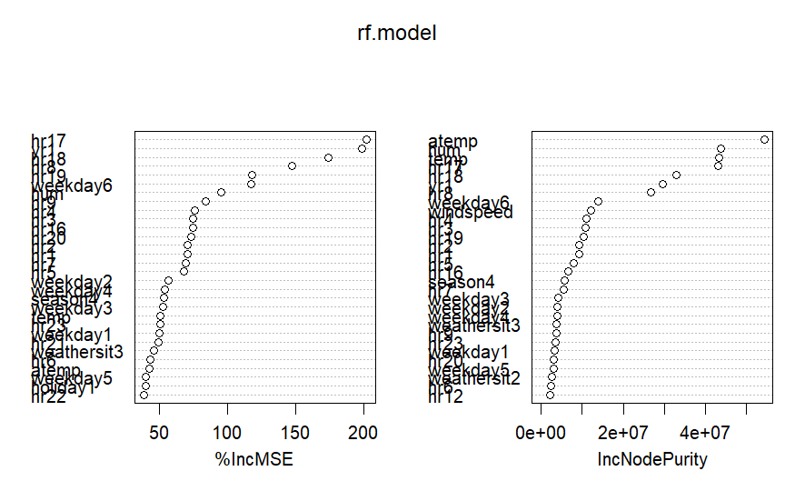

```r
varImpPlot(rf.model)
```

#### Plotting the Actual values Vs Predicted vaues

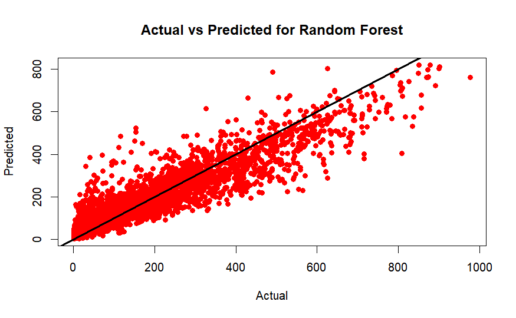

```r
plot(dff$cnt[-trainIndex], yhat.rf, pch = 16, col = "red", main = "Actual vs Predicted for Random Forest", xlab = "Actual", ylab = "Predicted")
abline(a = 0, b = 1, col = "black",lty=1,lwd=3)
```

```r
# Display the results
cat("R-squared: ", r_squared_rf, "\n")
```

```
R-squared:  0.8443822
```

```r
cat("Mean Square Error (MsE): ", mse_rf, "\n")
```

```
Mean Square Error (MsE):  4987.375
```

```r
cat("Mean Absolute Error (MAE): ", mae_rf, "\n")
```

```
Mean Absolute Error (MAE):  47.14141
```

```r
cat("Root Mean Square Error (RMSE): ", rmse_rf, "\n")
```

```
Root Mean Square Error (RMSE):  70.62135
```

```r
set.seed(1)
boost.model = gbm(cnt~.,data=dff[trainIndex,],distribution="gaussian",n.trees=5000,cv.folds = 5,interaction.depth=6)
```